# Estudios de Informática, Multimedia y Telecomunicaciones

# Tipología y ciclo de vida de los datos: PRÁCTICA 2

David Durán Olivar & Pablo Martínez Pavón

Diciembre 2021

El objetivo de la presente práctica será el tratamiento de un dataset.

Se ha elegido el dataset [Prosper loan data](https://www.kaggle.com/shikhar07/prosper-loan-data).

El significado de cada una de las variables puede encontrarse en el siguiente [enlace](https://docs.google.com/spreadsheets/d/1gDyi_L4UvIrLTEC6Wri5nbaMmkGmLQBk-Yx3z0XDEtI/edit#gid=0).

Los datos corresponden a un rango temporal específico, que se definirá durante el análisis de los datos. Por lo tanto, en el contexto de la adquisición de los datos se trata de un archivo único, no habría que plantear un ETL para una carga incremental.

La licencia de estos datos no está especificada en Kaggle.

Los datos con los que se trabajará han sido descargados en formato CSV.

Para el planteamiento de esta actividad se seguirá la metodología CRISP-DM. En el caso de la presente práctica, se implementarán las siguientes fases, esto es:

1. *Comprensión del negocio*.
- Objetivo: Definir el resultado esperado.
- Producto que se obtiene: Objetivo específico del proyecto.
- Ejemplo de tareas: las principales preguntas a responder que se plantearán en el apartado correspondiente.
  2. *Comprensión de los datos*.
- Objetivo: Entender la correspondencia entre los datos y la realidad.
- Producto que se obtiene: entendimiento de los datos.
- Ejemplo: conocer la estructura de los datos, entender como se relacionan entre sí y con el mundo real. Posteriormente, se explica la tipología de los datos y su correspondencia con la realidad.
  3. *Preparación de los datos*.
- Objetivo: adquirir los datos, tratarlos (limpiarlos, filtrarlos, etc.),..
- Producto que se obtiene: dataset preparado para trabajar con él (datos válidos y significativos).
- Ejemplo: limpieza de datos (detección de datos vacíos y nulos, no consideración de datos redundantes, errores de formato, etc.), reducción de dimensiones,etc.
  4. *Modelado*.
- Objetivo: Desarrollar un modelo que en base al dataset disponible permita lograr el objetivo propuesto en la primera fase.
- Producto que se obtiene: Modelo para predecir si el producto presenta las caracerísticas adecuadas para su venta.
- Ejemplo: partiendo de que el resultado esperado fuese una variable categórica (OK o NO_OK), se trataría de un modelo (por ejemplo, logístico) para predecir la posibilidad de que el solicitante vaya a incurrir en morosidad.
  5. *Evaluación*.
- Objetivo: testear el sistema de predicción con nuevos datos y validad su correcto funcionamiento.
- Producto que se obtiene: validación del modelo planteado.
- Ejemplo: Comprobar que el modelo tiene sentido desde un punto de vista no solo estadísitco, sino que en el mundo real existen razones para dar por buenos los resultados del modelo (Relación con la fase de Comprensión del negocio).

La fase de *Implantación* queda fuera del alcance de la presente actividad, por tratarse de un desarrollo teórico sobre el papel.

Inicialmente, procedemos a la carga de los datos.

```r
#lectura
datos<-read.csv("D:/Users/pablo/OneDrive/Escritorio/CICLO PRAC2/prosperLoanData.csv",
                header=T, sep=",")
#attach(datos)
```

# 1 Descripción del Dataset.

En primer lugar, analizamos las dimensiones del dataset.

```r
#dimensiones
sprintf("El dataset presenta las siguientes dimensiones: %.f registros y %.f variables.",
        dim(datos)[1], dim(datos)[2])
```

```
## [1] "El dataset presenta las siguientes dimensiones: 113937 registros y 81 variables."
```

Comprobamos si existen valores duplicados:

```r
#duplicados
summary(duplicated(datos))
```

```
##    Mode   FALSE
## logical  113937
```

Se comprueba que no existen valores duplicados.

Previo a la conversión de las variables a su tipo correspondiente, y en base a la explicación facilitada en la web, se describen cada una de las variables correspondientes y el tipo que deberían presentar.

- ListingKey: Clave única para cada listado, el mismo valor que la ‘clave’ utilizada en el objeto de listing en la API. String (factor).
- ListingNumber: El número que identifica de forma exclusiva el listing para el público tal como se muestra en el sitio web. Integer (factor).
- ListingCreationDate: La fecha en que se creó el listado. Date.
- CreditGrade: La calificación crediticia que se asignó en el momento en que se publicó el anuncio. Se aplica a los anuncios del período anterior a 2009 y solo se completará para esos anuncios. String (factor).
- Term: La duración del préstamo expresada en meses. Integer.
- LoanStatus: El estado actual del préstamo: Cancelled, Chargedoff, Completed, Current, Defaulted, FinalPaymentInProgress, PastDue. El estado PastDue irá acompañado de un aviso de morosidad. String (factor).
- ClosedDate: La fecha de cierre se aplica a los estados de préstamos Cancelled, Completed, Chargedoff and Defaulted. Date.
- BorrowerAPR: La tasa de porcentaje anual (APR, en castellano TAE) del préstamo. Numeric.
- BorrowerRate: La tasa de interés del prestatario para este préstamo. Numeric.
- LenderYield: El rendimiento del prestamista sobre el préstamo. El rendimiento del prestamista es igual a la tasa de interés del préstamo menos la tarifa de servicio. Numeric.
- EstimatedEffectiveYield: El rendimiento efectivo es igual a la tasa de interés del prestatario (i) menos la tasa de la tarifa de servicio, (ii) menos los intereses no cobrados estimados sobre cancelaciones, (iii) más los cargos por mora cobrados estimados. Aplica para préstamos originados después de julio de 2009. Numeric.
- EstimatedLoss: La pérdida estimada es la pérdida de principal estimada en los charge-offs. Aplica para préstamos originados después de julio de 2009. Numeric.
- EstimatedReturn: El rendimiento estimado asignado al listado en el momento de su creación. El rendimiento estimado es la diferencia entre el rendimiento efectivo estimado y la tasa de pérdida estimada. Aplica para préstamos originados después de julio de 2009. Numeric.
- ProsperRating (numérico): La calificación de Prosper asignada en el momento en que se creó el listing: 0 - N / A, 1 - HR, 2 - E, 3 - D, 4 - C, 5 - B, 6 - A, 7 - AA. Aplica para préstamos originados después de julio de 2009. Integer (factor).
- ProsperRating (Alfa): La calificación de Prosper asignada en el momento en que se creó la cotización entre AA - HR. Aplica para préstamos originados después de julio de 2009. String (factor).
- ProsperScore: Una puntuación de riesgo personalizado creado a partir de datos históricos de Prosper. La puntuación varía de 1 a 10, siendo 10 la mejor puntuación de riesgo o la más baja. Aplica para préstamos originados después de julio de 2009. Integer (factor).
- ListingCategory: La categoría del listado que el prestatario seleccionó al publicar su listado: 0 - No disponible, 1 - Consolidación de deuda, 2 - Mejoras para el hogar, 3 - Negocios, 4 - Préstamo personal, 5 - Uso de estudiantes, 6 - Automóvil, 7- Otro, 8 - Bebé y adopción, 9 - Barco, 10 - Procedimiento cosmético, 11 - Anillo de compromiso, 12 - Préstamos ecológicos, 13 - Gastos del hogar, 14 - Grandes compras, 15 - Médico / dental, 16 - Motocicleta, 17 - RV, 18 - Impuestos, 19 - Vacaciones, 20 - Préstamos para bodas. Integer (factor).
- BorrowerState: La abreviatura de dos letras del estado de la dirección del prestatario en el momento en que se creó el listado. String.
- Ocupación: La ocupación seleccionada por el Prestatario en el momento en que creó el listado. String (factor).
- EmploymentStatus: El estado laboral del prestatario en el momento en que publicó la lista. String (factor).
- EmploymentStatusDuration: La duración en meses del estado laboral en el momento en que se creó la lista. Integer.
- IsBorrowerHomeowner: Un prestatario será clasificado como propietario de vivienda si tiene una hipoteca en su perfil crediticio o proporciona documentación que confirme que es propietario de vivienda. Boolean (factor).
- CurrentInGroup Especifica si el prestatario estaba o no en un grupo en el momento en que se creó la lista. Boolean (factor).
- GroupKey: La clave del grupo al que pertenece el prestatario. El valor será nulo si el prestatario no tiene una afiliación grupal. String.
- DateCreditPulled: La fecha en que se extrajo el perfil de crédito. Date.
- CreditScoreRangeLower: El valor más bajo que representa el rango del puntaje crediticio del prestatario proporcionado por una agencia de calificación crediticia del consumidor. Integer.
- CreditScoreRangeUpper: El valor superior que representa el rango del puntaje crediticio del prestatario proporcionado por una agencia de calificación crediticia del consumidor. Integer.
- FirstRecordedCreditLine: La fecha en que se abrió la primera línea de crédito. Date.
- CurrentCreditLines: Número de líneas de crédito actuales en el momento en que se extrajo el perfil de crédito. Integer.
- OpenCreditLines: Número de líneas de crédito abiertas en el momento en que se extrajo el perfil de crédito. Integer.
- TotalCreditLinespast7years: Número de líneas de crédito en los últimos siete años en el momento en que se extrajo el perfil crediticio. Integer.
- OpenRevolvingAccounts: Número de cuentas renovables abiertas en el momento en que se extrajo el perfil crediticio. Integer.
- OpenRevolvingMonthlyPayment: Pago mensual en cuentas renovables en el momento en que se extrajo el perfil crediticio. Integer.
- InquiriesLast6Months: Número de consultas para pedir crédito en los últimos seis meses en el momento en que se extrajo el perfil de crédito. Integer.
- TotalInquiries: Número total de consultas en el momento en que se extrajo el perfil crediticio. Integer.
- CurrentDelinquencies: Número de cuentas morosas en el momento en que se extrajo el perfil crediticio. Integer.
- AmountDelinquent: Dólares morosos en el momento en que se extrajo el perfil crediticio. Integer.
- DelinquenciesLast7Years: Número de morosidad en los últimos 7 años en el momento en que se extrajo el perfil crediticio. Integer.
- PublicRecordsLast10Years: Número de registros públicos en los últimos 10 años en el momento en que se extrajo el perfil crediticio. Integer.
- PublicRecordsLast12Months: Número de registros públicos en los últimos 12 meses en el momento en que se extrajo el perfil crediticio. Integer.
- RevolvingCreditBalance: Dólares de crédito revolving en el momento en que se extrajo el perfil crediticio. Integer.
- BankcardUtilization: El porcentaje de crédito revolving disponible que se utiliza en el momento en que se extrajo el perfil crediticio. Numeric.
- AvailableBankcardCredit: El crédito total disponible mediante tarjeta bancaria en el momento en que se extrajo el perfil de crédito. Integer.
- TotalTrades: Número de líneas comerciales abiertas en el momento en que se extrajo el perfil crediticio. Integer.
- TradesNeverDelinquent: Número de operaciones que nunca han estado en mora en el momento en que se extrajo el perfil crediticio. Numeric.
- TradesOpenedLast6Months: Número de operaciones abiertas en los últimos 6 meses en el momento en que se extrajo el perfil crediticio. Integer.
- DebtToIncomeRatio: La relación deuda / ingresos del prestatario en el momento en que se extrajo el perfil crediticio. Este valor es nulo si la relación deuda / ingresos no está disponible. Este valor tiene un tope de 10.01 (cualquier relación de deuda a ingresos superior al 1000% se devolverá como 1001%). Numeric.
- IncomeRange: El rango de ingresos del prestatario en el momento en que se creó la lista. String (factor).
- IncomeVerificable: El prestatario indicó que tiene la documentación requerida para respaldar sus ingresos. Boolean (factor).
- StatedMonthlyIncome: El ingreso mensual que el prestatario declaró en el momento en que se creó la lista. Numeric.
- LoanKey: Clave única para cada préstamo. Esta es la misma clave que se usa en la API. String.
- TotalProsperLoans: Número de préstamos Prosper que el prestatario en el momento de crear este listado. Este valor será nulo si el prestatario no ha tenido préstamos anteriores. Integer.
- TotalProsperPaymentsBilled: Número de pagos puntuales que el prestatario realizó sobre los préstamos Prosper en el momento de crear esta lista. Este valor será nulo si el prestatario no ha tenido préstamos anteriores. Integer.
- OnTimeProsperPayments: Número de pagos puntuales que el prestatario había realizado en préstamos Prosper en el momento de crear esta lista. Este valor será nulo si el prestatario no tiene préstamos previos. Integer.
- ProsperPaymentsLessThanOneMonthLate: Número de pagos que el prestatario realizó sobre préstamos Prosper que tenían menos de un mes de retraso en el momento de crear esta lista. Este valor será nulo si el prestatario no ha tenido préstamos anteriores. Integer.
- ProsperPaymentsOneMonthPlusLate: Número de pagos que el prestatario realizó en préstamos Prosper que tenían más de un mes de retraso en el momento en que crearon esta lista. Este valor será nulo si el prestatario no ha tenido préstamos anteriores. Integer.
- ProsperPrincipalBorrowed: Principal total prestado sobre préstamos Prosper en el momento en que se creó la cotización. Este valor será nulo si el prestatario no ha tenido préstamos anteriores. Integer.
- ProsperPrincipal: Principal pendiente de pago de los préstamos Prosper en el momento en que se creó la cotización. Este valor será nulo si el prestatario no ha tenido préstamos anteriores. Numeric.
- ScorexChangeAtTimeOfListing La calificación crediticia del prestatario cambió en el momento en que se extrajo el perfil crediticio. Este será el cambio relativo al último préstamo Prosper del prestatario. Este valor será nulo si el prestatario no ha tenido préstamos anteriores. Integer.
- LoanCurrentDaysDelinquent: El número de días de mora. Integer.
- LoanFirstDefaultedCycleNumber: El ciclo en el que se canceló el préstamo. Si el préstamo no se ha cancelado el valor será nulo. Integer.
- LoanMonthsSinceOrigination: Número de meses desde que se originó el préstamo. Integer.
- LoanNumber: Valor numérico único asociado con el préstamo. Integer.
- LoanOriginalAmount: El monto de origen del préstamo. Integer.
- LoanOriginationDate: La fecha en que se originó el préstamo. Date.
- LoanOriginationQuarter: El trimestre en el que se originó el préstamo. String.
- MemberKey: La clave única que está asociada con el prestatario. Este es el mismo identificador que se utiliza en el objeto miembro de API. String (factor).
- MonthlyLoanPayment: El pago mensual programado del préstamo. Numeric.
- LP_CustomerPayments: Pagos brutos acumulativos previos a la cancelación efectuados por el prestatario sobre el préstamo. Si el préstamo se ha cancelado, este valor excluirá cualquier recuperación. Numeric.
- LP_CustomerPrincipalPayments: Pagos de principal acumulados antes de la cancelación efectuados por el prestatario sobre el préstamo. Si el préstamo se ha cancelado, este valor excluirá cualquier recuperación. Numeric.
- LP_InterestandFees: Intereses acumulados y tarifas pagadas por el prestatario antes de la cancelación. Si el préstamo se ha cancelado, este valor excluirá cualquier recuperación. Numeric.
- LP_ServiceFees: Tarifas de servicio acumuladas pagadas por los inversores que han invertido en el préstamo. Numeric.
- LP_CollectionFees: Comisiones de cobranza acumuladas pagadas por los inversores que han invertido en el préstamo. Numeric.
- LP_GrossPrincipalLoss: El monto de cargo bruto del préstamo. Numeric.
- LP_NetPrincipalLoss: El principal que permanece sin cobrar después de cualquier recuperación. Numeric.
- LP_NonPrincipalRecoverypayments: El componente de interés y tarifa de cualquier pago de recuperación. La política de pagos actual aplica los pagos en el siguiente orden: honorarios, intereses, principal. Numeric.
- PercentFunded: Porcentaje de financiación del préstamo. Numeric.
- Recomendaciones: Número de recomendaciones que tenía el prestatario en el momento en que se creó la lista. Integer.
- InvestmentFromFriendsCount: Número de amigos que hicieron una inversión en el préstamo. Integer.
- InvestmentFromFriends: Monto en dólares de inversiones realizadas por amigos. Integer.
- Inversores: El número de inversores que financiaron el préstamo.

Observamos que en definitiva,se analizan las características generales del préstamo y el perfil del prestatario, posteriomente cada una de las posibles fuentes de deuda (Líneas de crédito, créditos revolving, otros créditos prosper) y los datos del préstamo actual.

Antes de realizar el análisis inicial de los datos, se eliminarán las variables del dataset y se onvertirán a los tipos correspondientes las variables.

## 1.1 ¿Por qué es importante y qué pregunta/problema pretende responder?

[Prosper](https://www.prosper.com/) se fundó en 2005 como el primer mercado de préstamos P2P (peer to peer) en los Estados Unidos. Desde entonces, Prosper ha facilitado más de 14 mil millones $ en préstamos a más de 870.000 personas.

Este dataset ofrece multitud de criterios que nos permiten conocer las diferentes variables que caracterizan el perfil de las personas a las que se ha concedido un crédito desde Prosper. Así, mediante su análisis es posible inferir las características básicas de los préstamos que han salido bien y el perfil de las persoanas que pueden recibir un crédito en base a su perfil económico.

Prosper ofrece una herramienta que si bien funciona como un préstamo bancario, ofrece una herramienta novedosa ya que permite a particulares tanto invertir en estos préstamos y lograr un rédito financiero, como a personas que tienen dificultades para acceder a créditos tradicionales poder acceder a financiación.

Emplea la “Calificación Prosper” para posibles prestatarios basada en la estimación de la empresa de la “tasa de pérdida estimada” de ese prestatario. Según la compañía, esa cifra está “determinada por dos puntajes: (1) el puntaje de crédito, obtenido de una agencia oficial de informes crediticios, y (2) el scoring de Prosper, calculado internamente según la población de Prosper”. Las calificaciones de Prosper, de menor riesgo a mayor riesgo, están etiquetadas como AA, A, B, C, D, E y HR (“Alto riesgo”).

| Prosper rating | Estimated Average Annual Loss Rate |
| --- | --- |
| AA | 0.00–1.99% |
| A | 2.00–3.99% |
| B | 4.00–5.99% |
| C | 6.00–8.99% |
| D | 9.00–11.99% |
| E | 12.00–14.99% |
| HR | 15.00%+ |

De 2006 a 2009, Prosper operó un modelo de tasa variable. Prosper actuó como un mercado de subastas en línea al estilo de eBay, en el que los prestamistas y los prestatarios determinaban en última instancia las tasas de los préstamos mediante un sistema holandés similar a una subasta.

En agosto de 2008, aproximadamente el 18,5% de todo el dinero prestado a través de Prosper desde el inicio (febrero de 2006) hasta junio de 2008 se encontraba en algún tipo de morosidad. Además, más del 35% de todos los préstamos que se originaron en febrero de 2007 se encontraban en algún tipo de mora.

A partir del 19 de diciembre de 2010, Prosper presentó un nuevo folleto a la SEC (Securities and Exchange Commission), cambiando su modelo de negocio para utilizar tasas preestablecidas determinadas únicamente por Prosper con base en una fórmula que evalúa el riesgo crediticio de cada posible prestatario. Con el nuevo enfoque, los prestamistas ya no determinan la tasa del préstamo mediante el descubrimiento de precios en una subasta. En su lugar, simplemente eligen si invierten o no a la tasa que el algoritmo de fijación de precios de préstamos de Prosper asigna al préstamo después de analizar el informe crediticio y la información financiera del prestatario.

Al 24 de enero de 2010, Prosper informó que el 22,45% de todo el dinero prestado desde el inicio se había cancelado y un 2,51% adicional estaba en mora pero aún no se había cancelado. Las tasas de cancelación por categoría de puntaje de crédito oscilaron entre el 11.57% del dinero prestado a prestatarios con un puntaje de crédito de 760 o más y el 44.30% del dinero prestado a prestatarios con un puntaje de crédito por debajo de 600. Eric’s Credit Community informó resultados de morosidad generalmente consistentes, con una tasa de morosidad de 24 meses por grado de crédito para préstamos originados después del 1 de enero de 2006, que oscila entre el 11,8% para los préstamos ‘AA’ y el 61,6% para los préstamos ‘HR’. Las tasas de cancelación en muchos casos excedieron los intereses recibidos en las categorías de préstamos, lo que resultó en un rendimiento negativo. Erics informó que el rendimiento medio de los inversores de Prosper fue negativo del 2,00% y el rendimiento medio negativo de 2,28.

Después del relanzamiento de Prosper en julio de 2009 y la aplicación de directrices crediticias más estrictas para los prestatarios, la tasa de impago de préstamos de Prosper se ha reducido significativamente. El porcentaje de todos los préstamos con más de 6 meses de antigüedad y más de 1 mes de atraso se redujo a menos del 4%. Al 11 de agosto de 2010, los 4 meses que coinciden con estos criterios representan el porcentaje más bajo de retrasos en los pagos que Prosper ha visto desde el inicio.

[Fuente](https://en.wikipedia.org/wiki/Prosper_Marketplace)

Según informes del gobierno americano, el efecto de estos préstamoes es positivo, ya que después de la solicitud, los puntajes crediticios de los prestatarios aumentan y las tasas de utilización de sus tarjetas de crédito caen en relación con los no prestatarios a corto plazo. A largo plazo, los niveles de deuda total de los prestatarios son más altos que los de los no prestatarios. Las diferencias en la deuda hipotecaria son particularmente grandes y aumentan con el tiempo. A pesar del aumento de los niveles de deuda en relación con los no prestatarios, las tasas de morosidad de los prestatarios son significativamente más bajas.

[Fuente](https://www.federalreserve.gov/econres/feds/files/2019022pap.pdf)

Así, hemos identificado los siguientes objetivos:

Entre las preguntas que buscamos responder:

- Caracterización del perfil de las personas que piden este tipo de créditos.
- Distribución por Estados.
- Préstamos característicos (duración y cantidad solicitada).
- Descubrir el modelo del ProsperScoring.
- Descubrir que información del perfil crediticio permite inferir si se va a incurrir en morosidad.
- Descubrir las caracter´siticas de un préstamo que siempre es devuelto.

[Web Prosper - Enlace a los listings](https://www.prosper.com/listings)

# 2 Integración y selección de los datos de interés a analizar.

Mediante la selección de variables, realizamos una primera reducción de la dimensionalidad del dataset. Se han decidido eliminar las siguientes variables porque se considera que no significativas de cara a resolver las preguntas planteadas:

- ListingKey
- ListingNumber
- ProsperRating (numeric)
- GroupKey
- CurrentlyInGroup
- TotalCreditLinespast7years
- DelinquenciesLast7Years
- PublicRecordsLast10Years
- LoanKey
- LoanNumber
- LoanOriginationQuarter
- MemberKey
- Recommendations
- InvestmentFromFriendsCount
- InvestmentFromFriendsAmount

Las razones por las que se han descartado, son variadas: el tipo de dato, su antiguedad, etc.

```r
#eliminacion variables
datos$ListingKey<-NULL
datos$ListingNumber<-NULL
datos$ProsperRating..numeric.<-NULL
datos$GroupKey<-NULL
datos$CurrentlyInGroup<-NULL
datos$TotalCreditLinespast7years<-NULL
datos$DelinquenciesLast7Years<-NULL
datos$PublicRecordsLast10Years<-NULL
datos$LoanKey<-NULL
datos$LoanNumber<-NULL
datos$LoanOriginationQuarter<-NULL
datos$MemberKey<-NULL
datos$Recommendations<-NULL
datos$InvestmentFromFriendsAmount<-NULL
datos$InvestmentFromFriendsCount<-NULL
```

Además, observamos ciertas relaciones entre las variables:

EstimatedEffectiveYield = EstimatedLoss + EstimatedReturn

Podemos sumar en una única variable, los pagos atrasados de los créditos Prosper. (ProsperPaymentsOneMonthPlusLate+ProsperPaymentsLessThanOneMonthLate->ProsperPaymentsLate)

En lo referido al perfil del solicitante:

Para caracterizar las líneas revolving, solo mantendremos las siguientes variables: - OpenRevolvingMonthlyPayment - RevolvingCreditBalance

Así, sabremos la cantidad que se debe y la cuota mensual.

Para conocer las líneas de crédito, solo tendremos en cuenta el número de líneas en uso (abiertas).

Se mantienen las variables de solicitudes (inquiries).

Respecto al crédito bancario y los trades mantenemos las variables disponibles en este punto.

Respecto a los préstamos previos, también reduciremos el número de variables. No mantenemos el número concreto de préstamos prosper previos, pero sí las coutas pagadas en plazo y fuera de el, la cantidad de dinero que se debe, no así la solicitada, etc.

```r
#eliminacion variables
datos$EstimatedLoss<-NULL
datos$EstimatedReturn<-NULL

#datos$ProsperPaymentsLate<-rowSums(datos[,c("ProsperPaymentsLessThanOneMonthLate",
#"ProsperPaymentsOneMonthPlusLate")], na.rm=TRUE)
datos$ProsperPaymentsLessThanOneMonthLate<-NULL
datos$ProsperPaymentsOneMonthPlusLate<-NULL

datos$OpenRevolvingAccounts<-NULL

datos$CurrentCreditLines<-NULL

datos$OnTimeProsperPayments<-datos$OnTimeProsperPayments/datos$TotalProsperPaymentsBilled
datos$TotalProsperPaymentsBilled<-NULL
datos$ProsperPrincipalBorrowed<-NULL

datos$ScorexChangeAtTimeOfListing<-NULL

datos$LoanFirstDefaultedCycleNumber<-NULL
datos$LoanMonthsSinceOrigination<-NULL
```

Se convierte cada variable al tipo que se ha indicado durante la descripción de las variables.

```r
#conversion dates
datos$ListingCreationDate<- as.Date(datos$ListingCreationDate)
datos$ClosedDate<- as.Date(datos$ClosedDate)
datos$DateCreditPulled<- as.Date(datos$DateCreditPulled)
datos$LoanOriginationDate<- as.Date(datos$LoanOriginationDate)
datos$FirstRecordedCreditLine<- as.Date(datos$FirstRecordedCreditLine)

#conversion factors
datos$CreditGrade<-as.factor(datos$CreditGrade)
#creamos un unico nivel Past Due
datos$LoanStatus[(grepl("Past Due",datos$LoanStatus))]<-"Past Due"
datos$LoanStatus<-as.factor(datos$LoanStatus)
datos$ProsperRating<-as.factor(datos$ProsperRating..Alpha.)
datos$ProsperRating..Alpha.<-NULL
#datos$ProsperScore<-as.factor(datos$ProsperScore)
datos$ListingCategory<-as.factor(datos$ListingCategory..numeric.)
datos$ListingCategory..numeric.<-NULL
datos$BorrowerState<-as.factor(datos$BorrowerState)
datos$Occupation<-as.factor(datos$Occupation)
datos$EmploymentStatus<-as.factor(datos$EmploymentStatus)
datos$IsBorrowerHomeowner<-as.factor(datos$IsBorrowerHomeowner)
datos$IncomeRange<-as.factor(datos$IncomeRange)
datos$IncomeVerifiable<-as.factor(datos$IncomeVerifiable)
```

Analizamos la estructura del dataset:

```r
# estructura
str(datos)
```

```
## 'data.frame':    113937 obs. of  55 variables:
##  $ ListingCreationDate               : Date, format: "2007-08-26" "2014-02-27" ...
##  $ CreditGrade                       : Factor w/ 9 levels "","A","AA","B",..: 5 1 8 1 1 1 1 1 1 1 ...
##  $ Term                              : int  36 36 36 36 36 60 36 36 36 36 ...
##  $ LoanStatus                        : Factor w/ 7 levels "Cancelled","Chargedoff",..: 3 4 3 4 4 4 4 4 4 4 ...
##  $ ClosedDate                        : Date, format: "2009-08-14" NA ...
##  $ BorrowerAPR                       : num  0.165 0.12 0.283 0.125 0.246 ...
##  $ BorrowerRate                      : num  0.158 0.092 0.275 0.0974 0.2085 ...
##  $ LenderYield                       : num  0.138 0.082 0.24 0.0874 0.1985 ...
##  $ EstimatedEffectiveYield           : num  NA 0.0796 NA 0.0849 0.1832 ...
##  $ ProsperScore                      : num  NA 7 NA 9 4 10 2 4 9 11 ...
##  $ BorrowerState                     : Factor w/ 52 levels "","AK","AL","AR",..: 7 7 12 12 25 34 18 6 16 16 ...
##  $ Occupation                        : Factor w/ 68 levels "","Accountant/CPA",..: 37 43 37 52 21 43 50 29 24 24 ...
##  $ EmploymentStatus                  : Factor w/ 9 levels "","Employed",..: 9 2 4 2 2 2 2 2 2 2 ...
##  $ EmploymentStatusDuration          : int  2 44 NA 113 44 82 172 103 269 269 ...
```

[output cut: 41 more lines]

También algunos de los principales parámetros estadísticos:

```r
# resumen
summary(datos)
```

```
##  ListingCreationDate   CreditGrade         Term
##  Min.   :2005-11-09          :84984   Min.   :12.00
##  1st Qu.:2008-09-19   C      : 5649   1st Qu.:36.00
##  Median :2012-06-16   D      : 5153   Median :36.00
##  Mean   :2011-07-08   B      : 4389   Mean   :40.83
##  3rd Qu.:2013-09-09   AA     : 3509   3rd Qu.:36.00
##  Max.   :2014-03-10   HR     : 3508   Max.   :60.00
##                       (Other): 6745
##                   LoanStatus      ClosedDate          BorrowerAPR
##  Cancelled             :    5   Min.   :2005-11-25   Min.   :0.00653
##  Chargedoff            :11992   1st Qu.:2009-07-14   1st Qu.:0.15629
##  Completed             :38074   Median :2011-04-05   Median :0.20976
##  Current               :56576   Mean   :2011-03-07   Mean   :0.21883
##  Defaulted             : 5018   3rd Qu.:2013-01-30   3rd Qu.:0.28381
##  FinalPaymentInProgress:  205   Max.   :2014-03-10   Max.   :0.51229
##  Past Due              : 2067   NA's   :58848        NA's   :25
##   BorrowerRate     LenderYield      EstimatedEffectiveYield  ProsperScore
##  Min.   :0.0000   Min.   :-0.0100   Min.   :-0.183          Min.   : 1.00
##  1st Qu.:0.1340   1st Qu.: 0.1242   1st Qu.: 0.116          1st Qu.: 4.00
##  Median :0.1840   Median : 0.1730   Median : 0.162          Median : 6.00
##  Mean   :0.1928   Mean   : 0.1827   Mean   : 0.169          Mean   : 5.95
##  3rd Qu.:0.2500   3rd Qu.: 0.2400   3rd Qu.: 0.224          3rd Qu.: 8.00
##  Max.   :0.4975   Max.   : 0.4925   Max.   : 0.320          Max.   :11.00
##                                     NA's   :29084           NA's   :29084
##  BorrowerState                      Occupation         EmploymentStatus
##  CA     :14717   Other                   :28617   Employed     :67322
##  TX     : 6842   Professional            :13628   Full-time    :26355
##  NY     : 6729   Computer Programmer     : 4478   Self-employed: 6134
##  FL     : 6720   Executive               : 4311   Not available: 5347
##  IL     : 5921   Teacher                 : 3759   Other        : 3806
##         : 5515   Administrative Assistant: 3688                : 2255
##  (Other):67493   (Other)                 :55456   (Other)      : 2718
##  EmploymentStatusDuration IsBorrowerHomeowner DateCreditPulled
##  Min.   :  0.00           False:56459         Min.   :2005-11-09
##  1st Qu.: 26.00           True :57478         1st Qu.:2008-09-16
##  Median : 67.00                               Median :2012-06-17
##  Mean   : 96.07                               Mean   :2011-07-09
##  3rd Qu.:137.00                               3rd Qu.:2013-09-11
##  Max.   :755.00                               Max.   :2014-03-10
##  NA's   :7625
```

[output cut: 89 more lines]

```
##  Min.   :    0.00                Min.   :0.7000   Min.   :   1.00
##  1st Qu.:    0.00                1st Qu.:1.0000   1st Qu.:   2.00
##  Median :    0.00                Median :1.0000   Median :  44.00
##  Mean   :   25.14                Mean   :0.9986   Mean   :  80.48
##  3rd Qu.:    0.00                3rd Qu.:1.0000   3rd Qu.: 115.00
##  Max.   :21117.90                Max.   :1.0125   Max.   :1189.00
##
##  ProsperRating   ListingCategory
##         :29084   1      :58308
##  C      :18345   0      :16965
##  B      :15581   7      :10494
##  A      :14551   2      : 7433
##  D      :14274   3      : 7189
##  E      : 9795   6      : 2572
##  (Other):12307   (Other):10976
```

```r
#dimensiones
sprintf("El dataset presenta las siguientes dimensiones: %.f registros y %.f variables.",
        dim(datos)[1], dim(datos)[2])
```

```
## [1] "El dataset presenta las siguientes dimensiones: 113937 registros y 55 variables."
```

Observamos como los préstamos en estado Complete o Charged off, no presentan la mayoría de los datos del perfil económico de los usuarios por lo que podremos separaremos tras ver que porcentaje representan sobre el total de los datos y algunos de los parámetros generales.

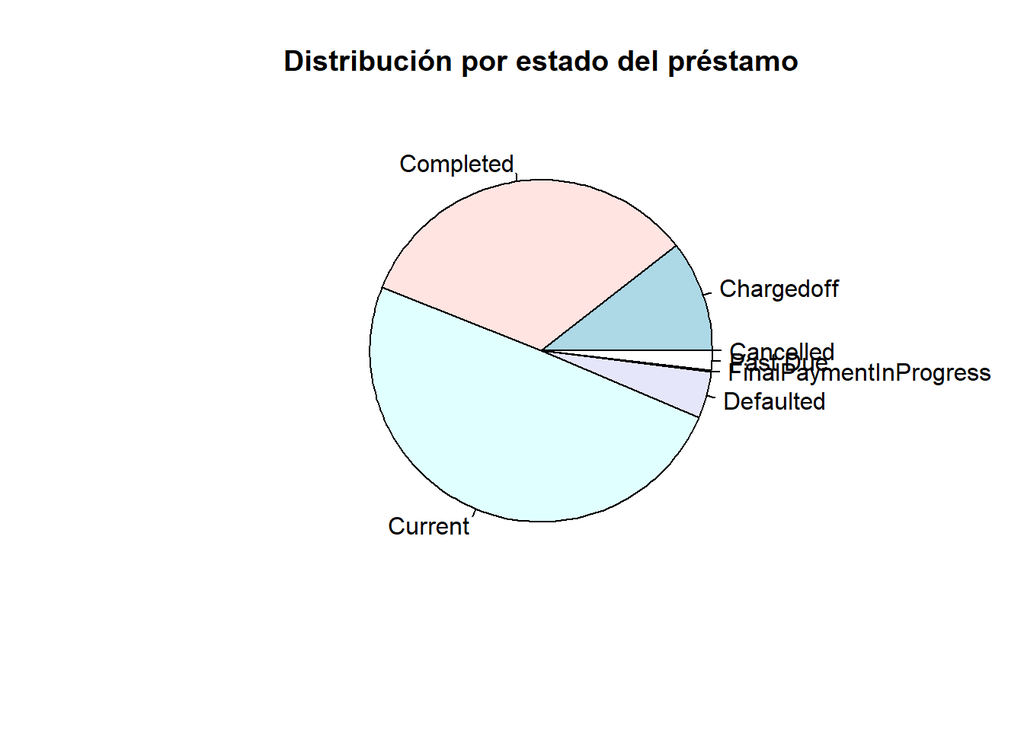

```r
#pie
pie(table(datos$LoanStatus), main="Distribución por estado del préstamo")
```

Observamos que Completed y Chargedoff son la segunda y tercera categoría con mayor número de registros respectivamente. Cancelled y FinalPaymentInProgress tienen un peso ínfimo sobre el total de los registros.

Comprobamos la distribución de los préstamos por número de meses y por cantidad solicitada:

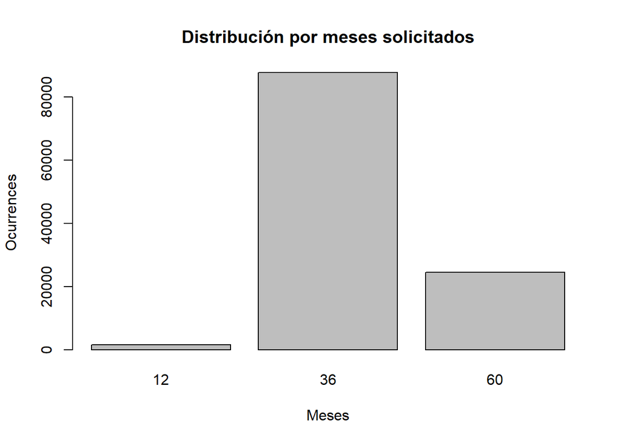

```r
#term
plot(as.factor(datos$Term), main="Distribución por meses solicitados",xlab="Meses", ylab="Ocurrences")
```

Se observa que de forma mayoritaria se solicitan préstamos a 36 meses.

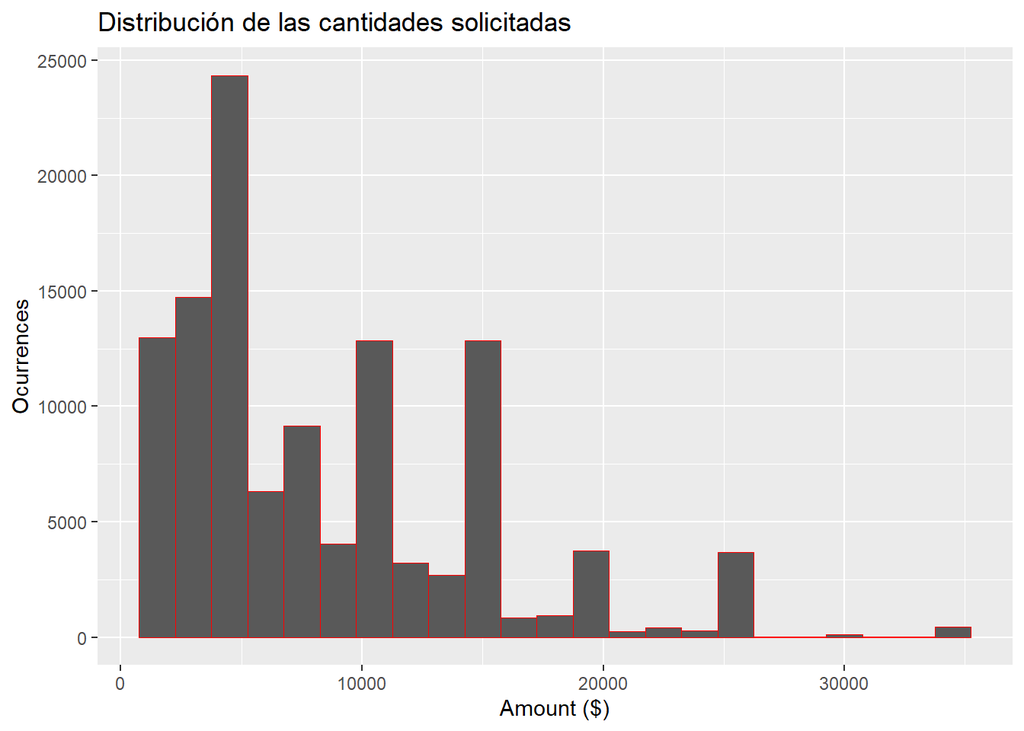

```r
library(ggplot2)

ggplot(aes(x = LoanOriginalAmount ) , data = datos) +
  geom_histogram(aes(), binwidth=1500, colour="red", lwd=0.2) +
   ggtitle("Distribución de las cantidades solicitadas") +
  xlab("Amount ($)") + ylab("Ocurrences")
```

Observamos que predominantemente se trata de préstamos por debajo de los 15.000 dólares.

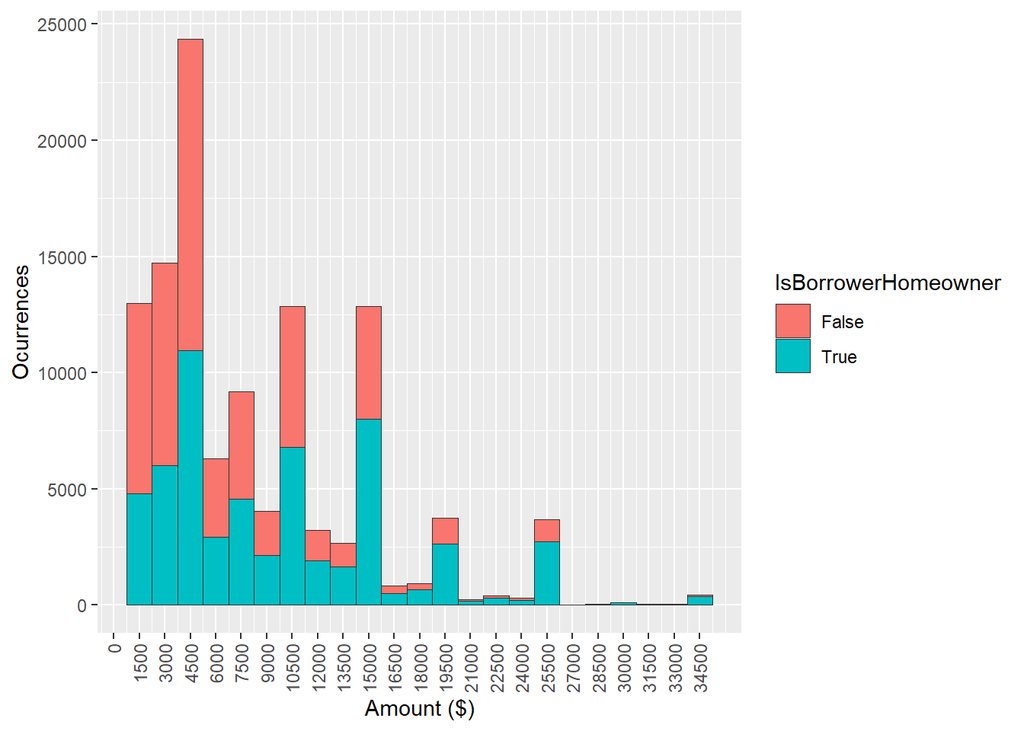

```r
ggplot(aes(x = LoanOriginalAmount ) , data = datos) +
  geom_histogram(aes(fill=IsBorrowerHomeowner), binwidth=1500, colour="grey20", lwd=0.2) +
  scale_x_continuous(breaks=seq(0,max(datos$LoanOriginalAmount), 1500))+
  theme(axis.text.x = element_text(angle = 90, vjust = 0.5, hjust=1))+
  xlab("Amount ($)") + ylab("Ocurrences")
```

Se comprueba como en los préstamos que solicitan mayor cantidad, presenta un mayor porcentaje de propietarios de viviendas.

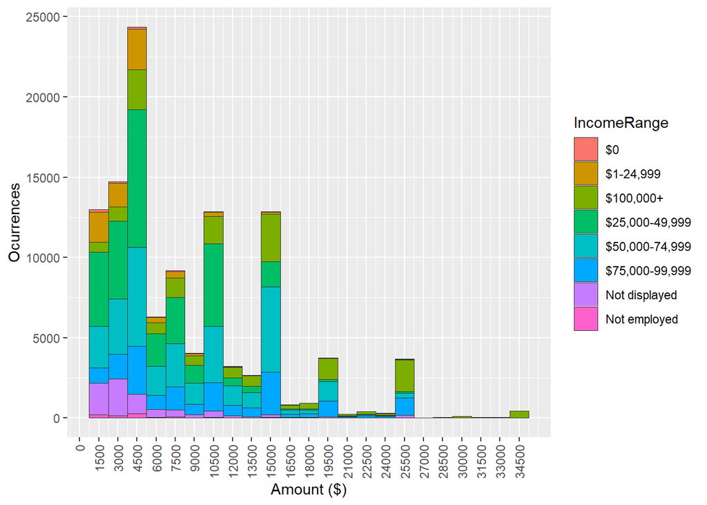

```r
ggplot(aes(x = LoanOriginalAmount ) , data = datos) +
  geom_histogram(aes(fill=IncomeRange), binwidth=1500, colour="grey20", lwd=0.2) +
  scale_x_continuous(breaks=seq(0,max(datos$LoanOriginalAmount), 1500))+
  theme(axis.text.x = element_text(angle = 90, vjust = 0.5, hjust=1))+
  xlab("Amount ($)") + ylab("Ocurrences")
```

Sí que se observa una cierta relación entre la cantidad solicitada y el rango salarial. Los mayores préstamos son solicitados por personas en los escalones más altos de salario.

Comprobamos esta hipótesis:

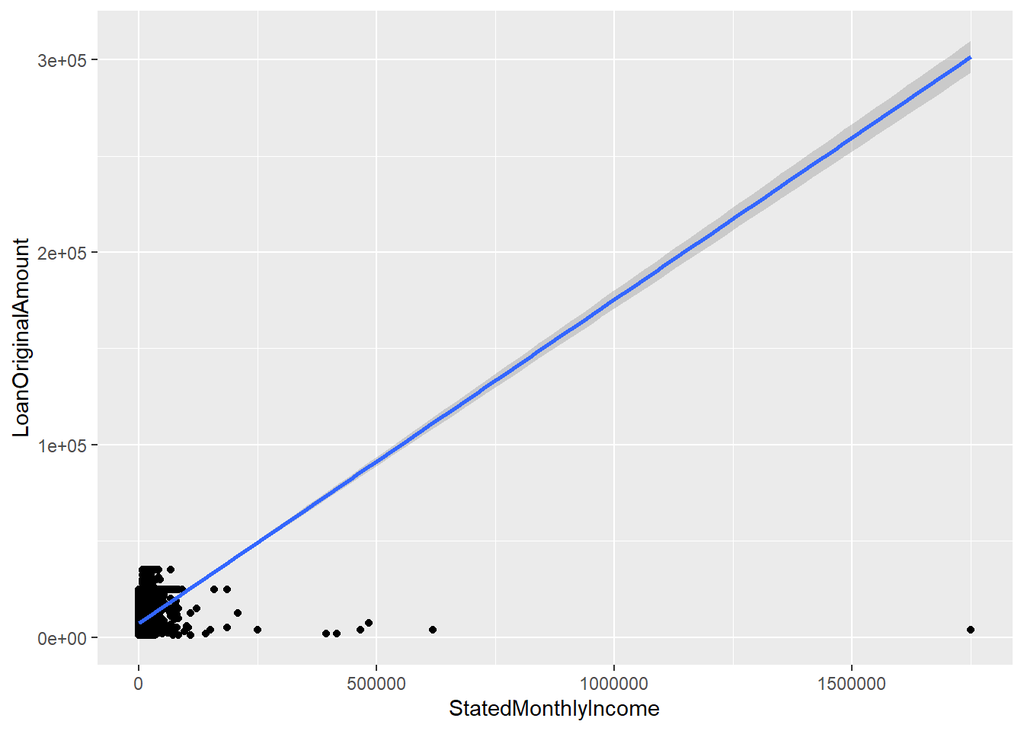

```r
#correlación entre amount y month_loan_duration
ggplot(datos, aes(x=StatedMonthlyIncome, y=LoanOriginalAmount)) +
  geom_point()+
  geom_smooth(method=lm)
```

Se observa que existen valores anómalos que impiden una correcta graficación, posteriormente se podrá volver a tratar estos datos.

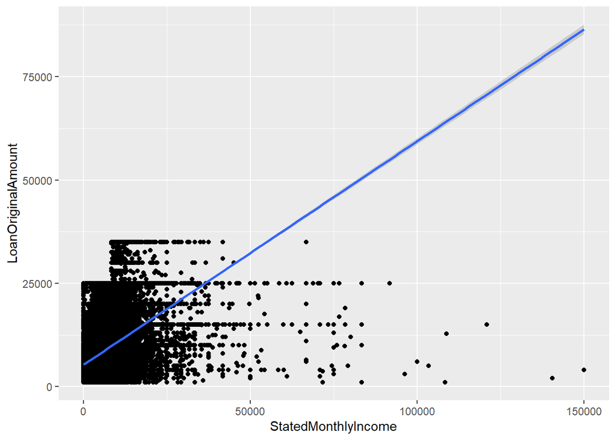

```r
#correlación entre amount y month_loan_duration
ggplot(datos, aes(x=StatedMonthlyIncome, y=LoanOriginalAmount)) +
  geom_point()+
  geom_smooth(method=lm)+xlim(0,150000)
```

La densidad representada impide observar claramente si existe correlación, pero en principio, parece que para una misma cantidad solicitada, existen solicitantes con muy diferente nivel de ingresos mensuales.

Graficamos otras variables que, ya de primeras, consideramos significativas a la hora de solicitar un préstamo.

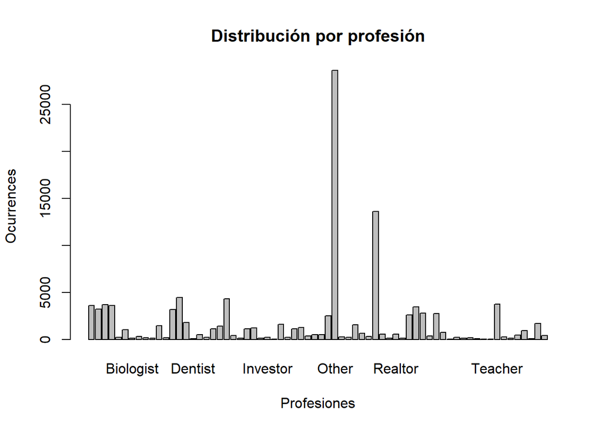

```r
plot(datos$Occupation, main="Distribución por profesión",xlab="Profesiones", ylab="Ocurrences")
```

Presentamos los resultados de la gráfica anterior, en una tabla

```r
library(dplyr)
tabla.ocupacion <- datos %>%
  group_by(Occupation) %>%
  summarise(count = n(),media=mean(LoanOriginalAmount))

#ordenado por ocurrences
head(tabla.ocupacion[order(tabla.ocupacion$count, decreasing=TRUE),],10)
```

```
## # A tibble: 10 x 3
##    Occupation                 count  media
##    <fct>                      <int>  <dbl>
##  1 "Other"                    28617  7805.
##  2 "Professional"             13628  9217.
##  3 "Computer Programmer"       4478  9421.
##  4 "Executive"                 4311 11891.
##  5 "Teacher"                   3759  7887.
##  6 "Administrative Assistant"  3688  6599.
##  7 "Analyst"                   3602  9161.
##  8 ""                          3588  5770.
##  9 "Sales - Commission"        3446  8763.
## 10 "Accountant/CPA"            3233  9196.
```

```r
#ordenado por media de lospréstamos solicitados
head(tabla.ocupacion[order(tabla.ocupacion$media, decreasing=TRUE),],10)
```

```
## # A tibble: 10 x 3
##    Occupation                 count  media
##    <fct>                      <int>  <dbl>
##  1 Judge                         22 14655.
##  2 Pharmacist                   257 13854.
##  3 Doctor                       494 13116.
##  4 Principal                    312 11977.
##  5 Executive                   4311 11891.
##  6 Pilot - Private/Commercial   199 11416.
##  7 Attorney                    1046 11305.
##  8 Dentist                       68 10915.
##  9 Engineer - Chemical          225 10831.
## 10 Nurse (RN)                  2489 10581.
```

```r
remove(tabla.ocupacion)
```

Observamos que por número de ocurrencias la categoría con más registros es Other. En el caso de por importe medio solicitado, vemos que en la mayoría son grupos con pocos registros; las diferencias entre ambas ordenaciones son reseñables, solo coincidiendo en ambos grupos Executive.

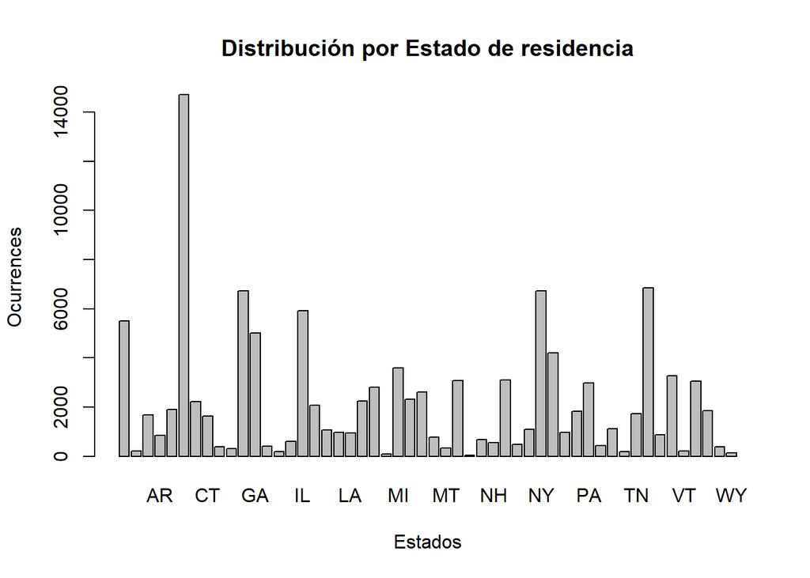

```r
plot(as.factor(datos$BorrowerState), main="Distribución por Estado de residencia",xlab="Estados", ylab="Ocurrences")
```

Observamos que gráficamente tampoco es posible interpretar todas las columnas, aunque sí que se comprueba que la distribución no es semejante entre estados. Generamos una tabla con estos datos.

```r
tabla.estados <- datos %>%
  group_by(BorrowerState) %>%
  summarise(count = n(),media=mean(LoanOriginalAmount))

#ordenado por ocurrences
head(tabla.estados[order(tabla.estados$count, decreasing=TRUE),],10)
```

```
## # A tibble: 10 x 3
##    BorrowerState count media
##    <fct>         <int> <dbl>
##  1 "CA"          14717 8974.
##  2 "TX"           6842 9088.
##  3 "NY"           6729 8833.
##  4 "FL"           6720 8207.
##  5 "IL"           5921 8396.
##  6 ""             5515 5412.
##  7 "GA"           5008 8363.
##  8 "OH"           4197 8078.
##  9 "MI"           3593 7645.
## 10 "VA"           3278 8971.
```

```r
#ordenado por media de lospréstamos solicitados
head(tabla.estados[order(tabla.estados$media, decreasing=TRUE),],10)
```

```
## # A tibble: 10 x 3
##    BorrowerState count  media
##    <fct>         <int>  <dbl>
##  1 DC              382 10126.
##  2 NJ             3097  9529.
##  3 MA             2242  9515.
##  4 NH              551  9463.
##  5 AK              200  9312.
##  6 MD             2821  9250.
##  7 HI              409  9148.
##  8 CT             1627  9130.
##  9 TX             6842  9088.
## 10 CA            14717  8974.
```

```r
remove(tabla.estados)
```

En este caso, tampoco hay grandes semejanzas entre ambas tablas, Con la excepción de CA y TX (California y Texas). California destaca por el número de préstamos, teniendo más del doble que el segundo estado de la tabla. Si nos vamos al dinero medio comprobamos que no existe tanta diferencia entre los estados.

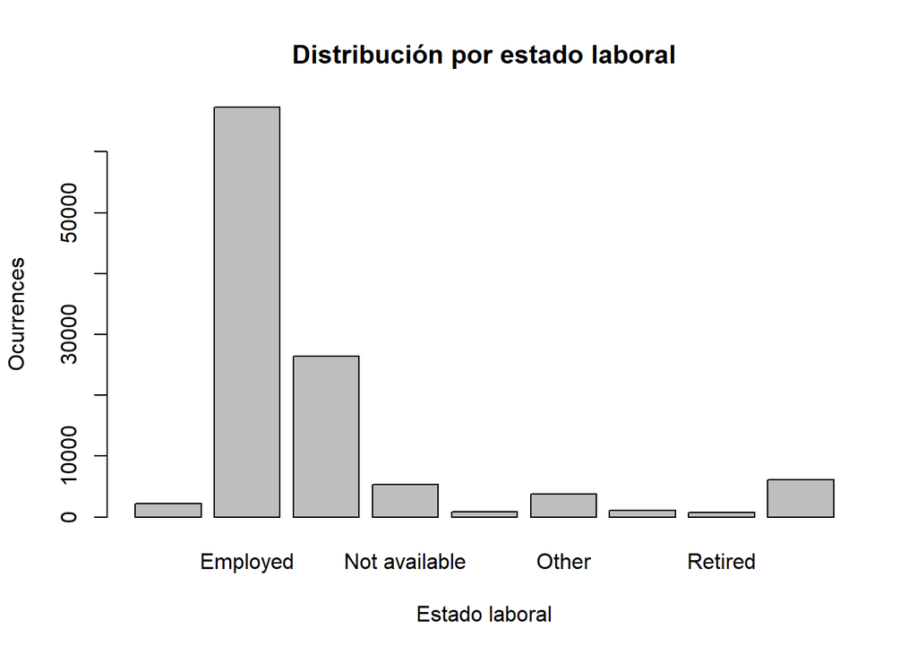

```r
plot(as.factor(datos$EmploymentStatus), main="Distribución por estado laboral",xlab="Estado laboral", ylab="Ocurrences")
```

```r
tabla.empleo <- datos %>%
  group_by(EmploymentStatus) %>%
  summarise(count = n(),media=mean(LoanOriginalAmount))

#ordenado por ocurrences
head(tabla.empleo[order(tabla.empleo$count, decreasing=TRUE),],10)
```

```
## # A tibble: 9 x 3
##   EmploymentStatus count media
##   <fct>            <int> <dbl>
## 1 "Employed"       67322 9794.
## 2 "Full-time"      26355 6195.
## 3 "Self-employed"   6134 8123.
## 4 "Not available"   5347 5373.
## 5 "Other"           3806 6862.
## 6 ""                2255 4563.
## 7 "Part-time"       1088 4089.
## 8 "Not employed"     835 4873.
## 9 "Retired"          795 4784.
```

```r
#ordenado por media de lospréstamos solicitados
head(tabla.empleo[order(tabla.empleo$media, decreasing=TRUE),],10)
```

```
## # A tibble: 9 x 3
##   EmploymentStatus count media
##   <fct>            <int> <dbl>
## 1 "Employed"       67322 9794.
## 2 "Self-employed"   6134 8123.
## 3 "Other"           3806 6862.
## 4 "Full-time"      26355 6195.
## 5 "Not available"   5347 5373.
## 6 "Not employed"     835 4873.
## 7 "Retired"          795 4784.
## 8 ""                2255 4563.
## 9 "Part-time"       1088 4089.
```

```r
remove(tabla.empleo)
```

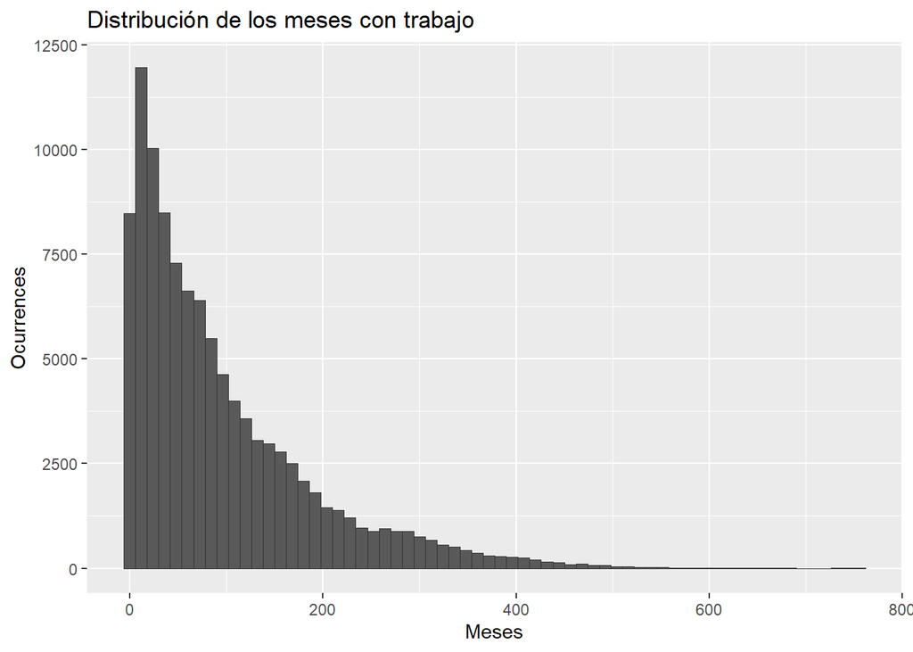

```r
ggplot(aes(x = EmploymentStatusDuration ) , data = datos) +
  geom_histogram(aes(), binwidth=12, colour="grey20", lwd=0.2) +
   ggtitle("Distribución de los meses con trabajo") +
  xlab("Meses") + ylab("Ocurrences")
```

Se ve que por lo general quienes solicitan préstamos tienen una menor cantidad de tiempo trabajado.

Con estos primeros análisis es posible hacer una primera descripción del perfil de persona que solicita estos préstamos: - Trabajadores por cuenta ajena temporales o indefinidos. - Poco tiempo trabajado. - Préstamos a 36 meses y menos de 15.000 dólares.

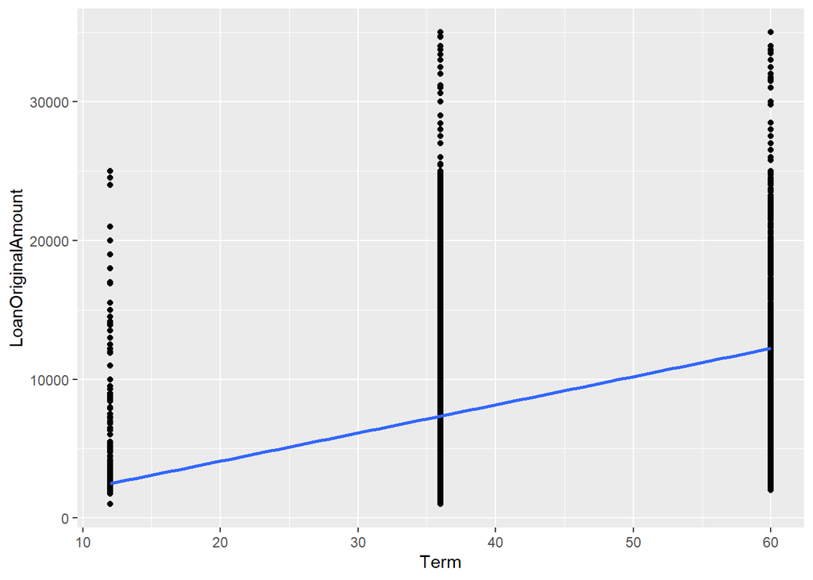

```r
#correlación entre amount y month_loan_duration
ggplot(datos, aes(x=Term, y=LoanOriginalAmount)) +
  geom_point()+
  geom_smooth(method=lm)
```

```r
tabla.rating <- datos %>%
  group_by(ProsperRating) %>%
  summarise(count = n(),media=mean(ProsperScore,na.rm = T))

#ordenado por ocurrences
head(tabla.rating[order(tabla.rating$count, decreasing=TRUE),],10)
```

```
## # A tibble: 8 x 3
##   ProsperRating count  media
##   <fct>         <int>  <dbl>
## 1 ""            29084 NaN
## 2 "C"           18345   5.47
## 3 "B"           15581   6.77
## 4 "A"           14551   8.02
## 5 "D"           14274   4.92
## 6 "E"            9795   3.69
## 7 "HR"           6935   3.60
## 8 "AA"           5372   9.49
```

```r
#ordenado por media de lospréstamos solicitados
head(tabla.rating[order(tabla.rating$media, decreasing=TRUE),],10)
```

```
## # A tibble: 8 x 3
##   ProsperRating count  media
##   <fct>         <int>  <dbl>
## 1 "AA"           5372   9.49
## 2 "A"           14551   8.02
## 3 "B"           15581   6.77
## 4 "C"           18345   5.47
## 5 "D"           14274   4.92
## 6 "E"            9795   3.69
## 7 "HR"           6935   3.60
## 8 ""            29084 NaN
```

```r
remove(tabla.rating)
```

Se comprueba que predominan los registros sin valor y que a la vista del score medio hay una correspondencia con el rating, si bien para las categorías más bajas E y HR, la distancia entre categorías se diluye.

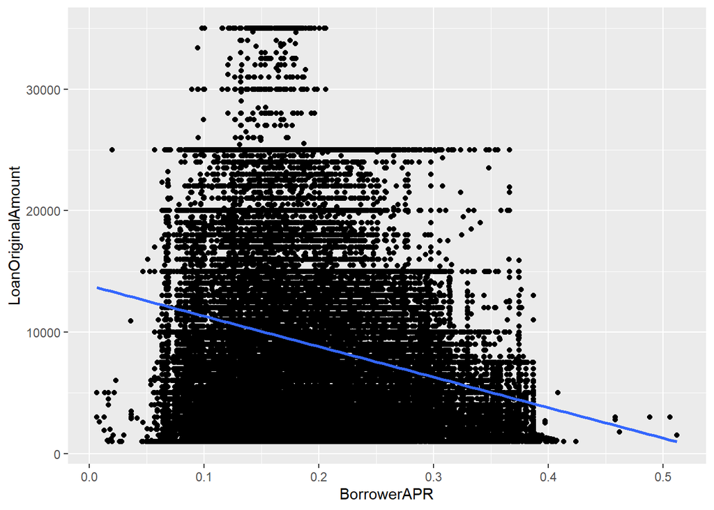

```r
#correlación entre amount y month_loan_duration
ggplot(datos, aes(x=BorrowerAPR, y=LoanOriginalAmount)) +
  geom_point()+
  geom_smooth(method=lm)
```

No existe una correlación clara entre la cantidad solicitada y el TAE que presenta el préstamo.

Mostramos la correlación entre todas las variables:

```r
#convertimos las variables categóricas a sus valores numéricos
#datos.num<-sapply(datos,as.numeric)
#datos.num<-scale(datos.num)
#library(corrplot)
#diagrama de correlación
#corrplot(cor(datos.num), type = "upper", order = "hclust",
#         tl.col = "black", tl.srt = 45, na.omit=T)
#remove(datos.num)
```

Se deben limpiar los registros antes de analizar la correlación.

# 3 Limpieza de los datos.

Aprovechamos la limpieza de cada variable para detectar anomalías y analizarla en detalle.

### 3.0.1 ListingCreationDate

```r
summary(datos$ListingCreationDate)
```

```
##         Min.      1st Qu.       Median         Mean      3rd Qu.         Max.
## "2005-11-09" "2008-09-19" "2012-06-16" "2011-07-08" "2013-09-09" "2014-03-10"
```

En el caso de esta variable, no hay valores que limpiar, y comprobamos que la creación de los listings va de 2005 a 2014.

### 3.0.2 Credit Grade

En este caso, como solo es válido antes del 2009 lo juntamos con Prosper Rating, ya que presentan los mismos niveles con la excepción de NC (No Credit).

```r
#niveles
levels(datos$CreditGrade)
```

```
## [1] ""   "A"  "AA" "B"  "C"  "D"  "E"  "HR" "NC"
```

```r
levels(datos$ProsperRating)
```

```
## [1] ""   "A"  "AA" "B"  "C"  "D"  "E"  "HR"
```

```r
#resumen
summary(datos$CreditGrade)
```

```
##           A    AA     B     C     D     E    HR    NC
## 84984  3315  3509  4389  5649  5153  3289  3508   141
```

```r
#pasamos los valores a rating
datos$ProsperRating[datos$ProsperRating==""]<-datos$CreditGrade
datos$CreditGrade<-NULL
```

Observamos que los valores vacíos se representan mediante "". Se han juntado las dos variables, se sabría diferenciar el origen de los datos de la nueva variable en función de la fecha.

### 3.0.3 Term

```r
summary(datos$Term)
```

```
##    Min. 1st Qu.  Median    Mean 3rd Qu.    Max.
##   12.00   36.00   36.00   40.83   36.00   60.00
```

No existen valores vacíos. Ya se graficó anteriormente, viendo que solo existen 3 niveles: 12, 36 y 60 meses.

### 3.0.4 LoanStatus

```r
summary(datos$LoanStatus)
```

```
##              Cancelled             Chargedoff              Completed
##                      5                  11992                  38074
##                Current              Defaulted FinalPaymentInProgress
##                  56576                   5018                    205
##               Past Due
##                   2067
```

No existen valores vacíos. Ya se graficó anteriormente.

### 3.0.5 ClosedDate

```r
summary(datos$ClosedDate)
```

```
##         Min.      1st Qu.       Median         Mean      3rd Qu.         Max.
## "2005-11-25" "2009-07-14" "2011-04-05" "2011-03-07" "2013-01-30" "2014-03-10"
##         NA's
##      "58848"
```

Se observa que hay muchos valores vacíos, esto se debe a que hay muchos préstamos que no están cerrados.

Los valores son congruentes con los de las fechas de creación.

Podemos asignar una fecha estimada de cierre en base al term, si suponemos meses de 30 días; sabríamos que fechas son reales y cuales estimadas en base al status.

```r
# asignamos nueva fecha
datos$ClosedDate[is.na(datos$ClosedDate)]<-datos$ListingCreationDate+datos$Term*30

summary(datos$ClosedDate)
```

```
##         Min.      1st Qu.       Median         Mean      3rd Qu.         Max.
## "2005-11-25" "2010-07-07" "2012-12-30" "2013-02-01" "2015-10-02" "2019-02-12"
```

Comprobamos que no habría valores vacíos.

### 3.0.6 BorrowerAPR

```r
summary(datos$BorrowerAPR)
```

```
##    Min. 1st Qu.  Median    Mean 3rd Qu.    Max.    NA's
## 0.00653 0.15629 0.20976 0.21883 0.28381 0.51229      25
```

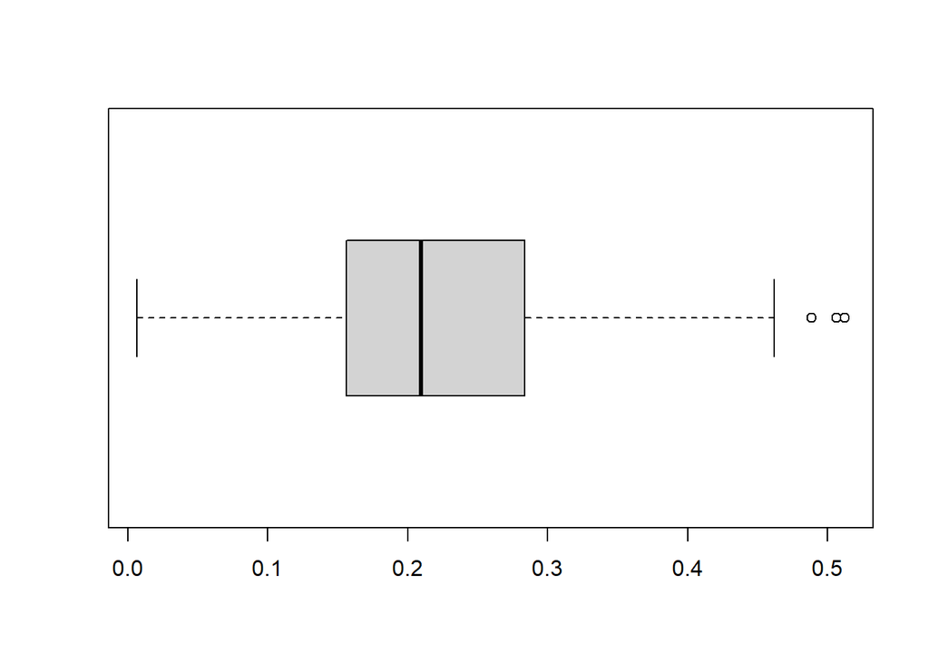

```r
boxplot(datos$BorrowerAPR, horizontal = T)
```

Observamos una gran variabilidad del TAE. Existen 25 valores vacíos que pueden completarse mediante regresión. Mediante el boxplot hemos identificado 3 valores que podrían ser tratados como outlier, pero nada indica que sean incorrectos.

```r
reg.lin.apr<-lm(BorrowerAPR~BorrowerRate+LenderYield,datos,na.action=na.omit)
summary(reg.lin.apr)
```

```
##
## Call:
## lm(formula = BorrowerAPR ~ BorrowerRate + LenderYield, data = datos,
##     na.action = na.omit)
##
## Residuals:
##       Min        1Q    Median        3Q       Max
## -0.036754 -0.006671  0.000202  0.007731  0.130416
##
## Coefficients:
##               Estimate Std. Error t value Pr(>|t|)
## (Intercept)  0.0156080  0.0001403  111.22   <2e-16 ***
## BorrowerRate 0.8698479  0.0114079   76.25   <2e-16 ***
## LenderYield  0.1944195  0.0114542   16.97   <2e-16 ***
## ---
## Signif. codes:  0 '***' 0.001 '**' 0.01 '*' 0.05 '.' 0.1 ' ' 1
##
## Residual standard error: 0.01142 on 113909 degrees of freedom
##   (25 observations deleted due to missingness)
## Multiple R-squared:  0.9798, Adjusted R-squared:  0.9798
## F-statistic: 2.763e+06 on 2 and 113909 DF,  p-value: < 2.2e-16
```

Conseguimos un buen modelo con un R2 ajustado elevado y en el que todas las variables son significativas. Con estos valores predecimos la variable APR.

```r
datos$BorrowerAPR[is.na(datos$BorrowerAPR)]<-predict(reg.lin.apr)

remove(reg.lin.apr)

summary(datos$BorrowerAPR)
```

```
##    Min. 1st Qu.  Median    Mean 3rd Qu.    Max.
## 0.00653 0.15629 0.20976 0.21882 0.28371 0.51229
```

Se comprueba que se han eliminado los na.

### 3.0.7 BorrowerRate

```r
summary(datos$BorrowerRate)
```

```
##    Min. 1st Qu.  Median    Mean 3rd Qu.    Max.
##  0.0000  0.1340  0.1840  0.1928  0.2500  0.4975
```

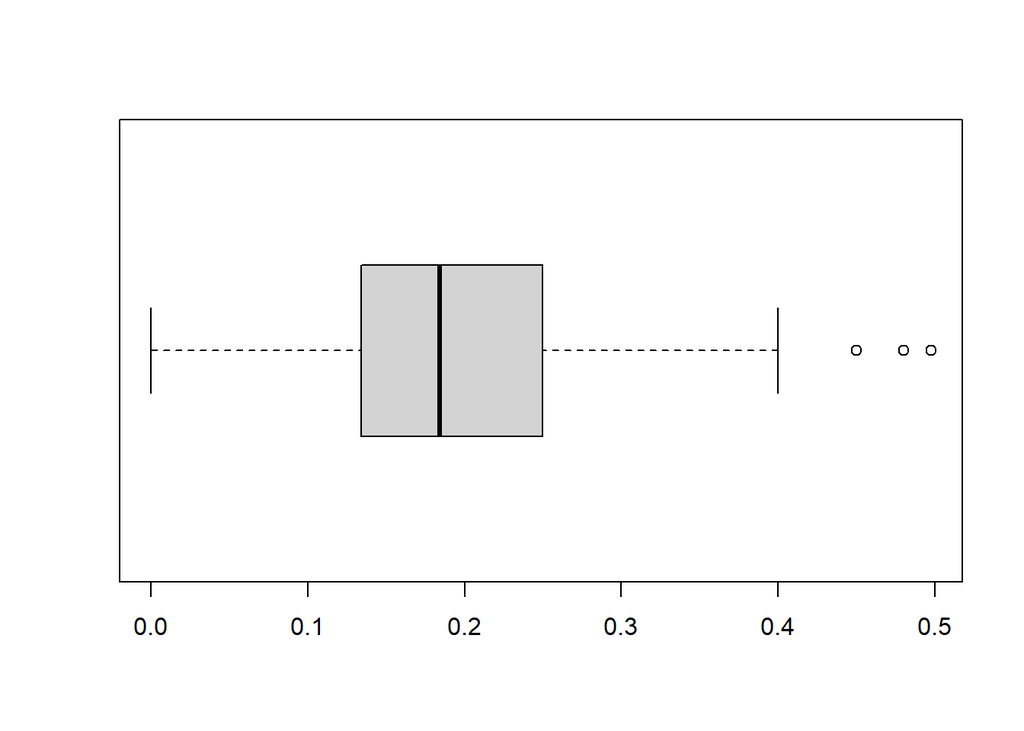

```r
boxplot(datos$BorrowerRate, horizontal = T)
```

En este caso, no hay valores vacíos y se detectan los mismos outliers.

### 3.0.8 LenderYield

```r
summary(datos$LenderYield)
```

```
##    Min. 1st Qu.  Median    Mean 3rd Qu.    Max.
## -0.0100  0.1242  0.1730  0.1827  0.2400  0.4925
```

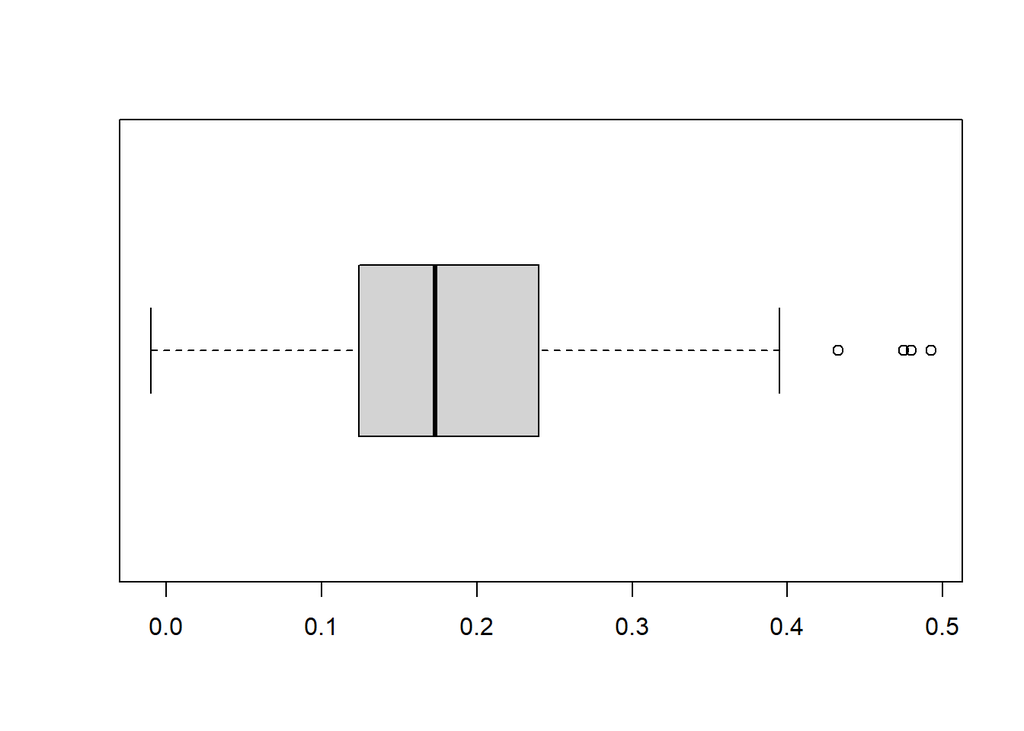

```r
boxplot(datos$LenderYield, horizontal = T)
```

Esta variable se comporta como las anteriores. Parecen presentar un elevado grado de correlación.

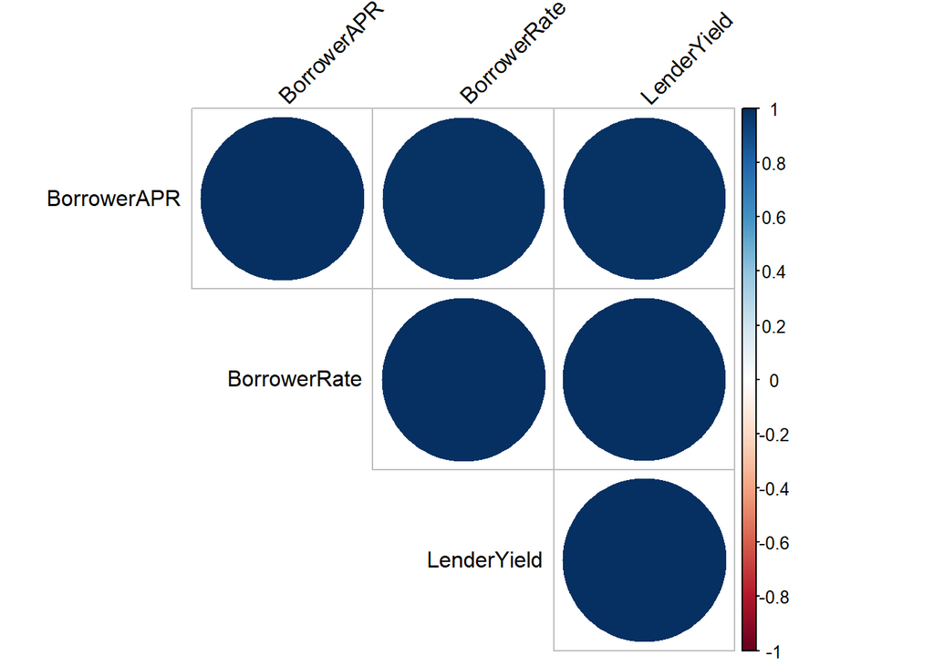

```r
library(corrplot)
#diagrama de correlación
corrplot(cor(datos[,5:7]), type = "upper", order = "hclust",
         tl.col = "black", tl.srt = 45, na.omit=T)
```

Se confirma, por lo que procedemos a descartar las dos últimas variables.

```r
datos$BorrowerRate<-NULL
datos$LenderYield<-NULL
```

### 3.0.9 EstimatedEffectiveYield

```r
summary(datos$EstimatedEffectiveYield)
```

```
##    Min. 1st Qu.  Median    Mean 3rd Qu.    Max.    NA's
##  -0.183   0.116   0.162   0.169   0.224   0.320   29084
```

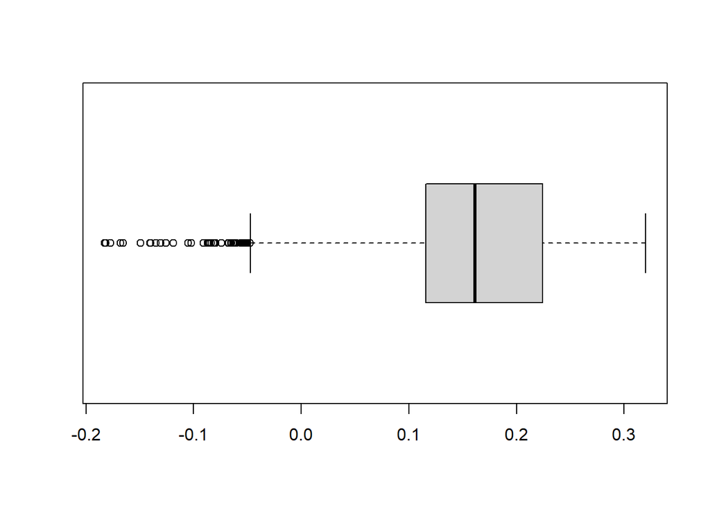

```r
boxplot(datos$EstimatedEffectiveYield,horizontal = T)
```

Comprobamos que existen muchos valores vacíos. C orresponden a préstamos previos a 2009 y que no están actualmente en curso.

Parece existir una relación con la variable ProsperScore, que presenta los mismos NA. Se detectan outliers en los valores negativos.

Trataremos como outliers los datos que se alejen 3 desviaciones estándar respecto a la media.

```r
datos$EstimatedEffectiveYield[datos$EstimatedEffectiveYield<(mean(datos$EstimatedEffectiveYield,
                                  na.rm = T)-3*sd(datos$EstimatedEffectiveYield,na.rm = T))]<-NA
```

Analizamos la relación con respecto a las variables actualmente tratadas.

```r
cor(datos[,5:6],use="complete.obs")
```

```
##                         BorrowerAPR EstimatedEffectiveYield
## BorrowerAPR               1.0000000               0.9075176
## EstimatedEffectiveYield   0.9075176               1.0000000
```

Se comprueba un elevado grado de correlación, sin embargo en este caso emplearemos otro método para inferir los valores. Plantemos usar KNN para inferir el valor de EstimatedEffectiveYield en los registros vacíos.

```r
#library(VIM)
#datos$EstimatedEffectiveYield[is.na(datos$EstimatedEffectiveYield)] <-
# kNN(datos)$EstimatedEffectiveYield
```

No es posible emplear este método por el tamaño del dataset, ya que se genera un vector de más de 15 Gb.

### 3.0.10 ProsperScore

```r
summary(datos$ProsperScore)
```

```
##    Min. 1st Qu.  Median    Mean 3rd Qu.    Max.    NA's
##    1.00    4.00    6.00    5.95    8.00   11.00   29084
```

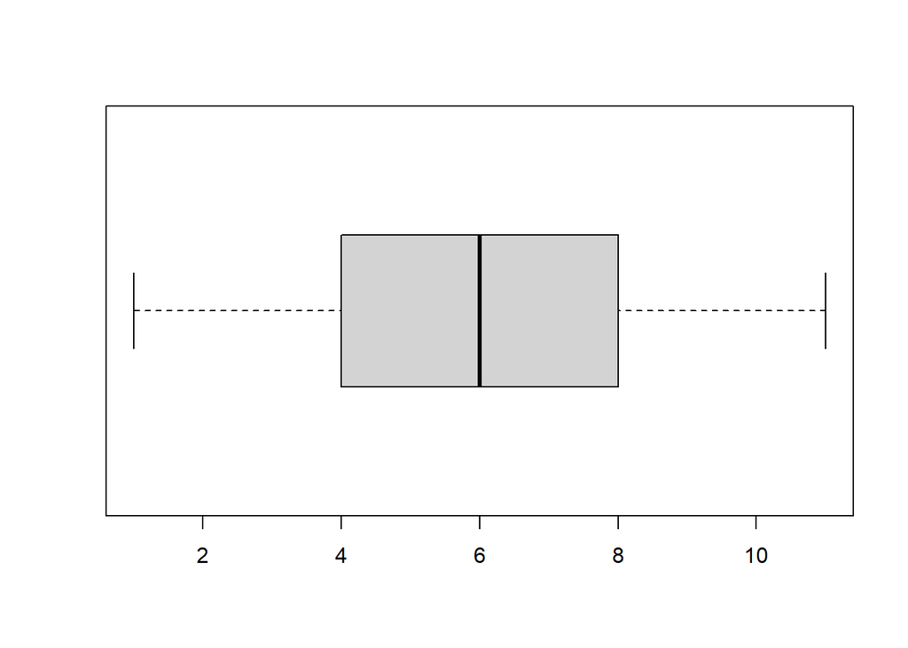

```r
boxplot(datos$ProsperScore,horizontal = T)
```

No se observan outliers en la representación gráfica, sin embargo vemos que hay valores por encima de 10 que se marca como el valor máximo. El número de NAs es igual al de la variable anterior. Tal y como se indicó en el apartado anterior, se analizó la relación entre los niveles de rating y el score medio podemos emplear estos datos para completarlo.

```r
#eliminamos los valores superiores a 10
datos$ProsperScore[datos$ProsperScore>10]<-NA

#media de rating
media.rating<-aggregate(x=datos$ProsperScore,
                              by= list(datos$ProsperRating),FUN=mean,na.rm=T)
rownames(media.rating)<-levels(media.rating$Group.1)

for (i in (1:(dim(datos)[1])))
  {
#asignamos a los valoresvacíos
      if  (is.na(datos$ProsperScore[i])){
        datos$ProsperScore[i]<-as.integer(media.rating[datos$ProsperRating[i],2])
      }

}

remove(i,media.rating)
```

Observamos que continúan existiendo valores con NA.

### 3.0.11 BorrowerState

```r
summary(datos$BorrowerState)
```

```
##          AK    AL    AR    AZ    CA    CO    CT    DC    DE    FL    GA    HI
##  5515   200  1679   855  1901 14717  2210  1627   382   300  6720  5008   409
##    IA    ID    IL    IN    KS    KY    LA    MA    MD    ME    MI    MN    MO
##   186   599  5921  2078  1062   983   954  2242  2821   101  3593  2318  2615
##    MS    MT    NC    ND    NE    NH    NJ    NM    NV    NY    OH    OK    OR
##   787   330  3084    52   674   551  3097   472  1090  6729  4197   971  1817
##    PA    RI    SC    SD    TN    TX    UT    VA    VT    WA    WI    WV    WY
##  2972   435  1122   189  1737  6842   877  3278   207  3048  1842   391   150
```

Observamos que existen 5.515 valores vacíos (""), en este caso con los datos disponibles no es posible indagar el valor a asignar.

### 3.0.12 Occupation

```r
summary(datos$Occupation)
```

```
##                                                        Accountant/CPA
##                               3588                               3233
##           Administrative Assistant                            Analyst
##                               3688                               3602
##                          Architect                           Attorney
##                                213                               1046
##                          Biologist                         Bus Driver
##                                125                                316
##                         Car Dealer                            Chemist
##                                180                                145
##                      Civil Service                             Clergy
##                               1457                                196
##                           Clerical                Computer Programmer
##                               3164                               4478
##                       Construction                            Dentist
##                               1790                                 68
##                             Doctor                Engineer - Chemical
##                                494                                225
##              Engineer - Electrical              Engineer - Mechanical
##                               1125                               1406
##                          Executive                            Fireman
##                               4311                                422
##                   Flight Attendant                       Food Service
##                                123                               1123
##            Food Service Management                          Homemaker
##                               1239                                120
##                           Investor                              Judge
##                                214                                 22
##                            Laborer                        Landscaping
##                               1595                                236
##                 Medical Technician                  Military Enlisted
##                               1117                               1272
##                   Military Officer                       Nurse's Aide
##                                346                                491
##                        Nurse (LPN)                         Nurse (RN)
##                                492                               2489
##                              Other                         Pharmacist
##                              28617                                257
##         Pilot - Private/Commercial  Police Officer/Correction Officer
##                                199                               1578
```

[output cut: 13 more lines]

```
##                                741                                 41
## Student - College Graduate Student           Student - College Junior
##                                245                                112
##           Student - College Senior        Student - College Sophomore
##                                188                                 69
##        Student - Community College         Student - Technical School
##                                 28                                 16
##                            Teacher                     Teacher's Aide
##                               3759                                276
##              Tradesman - Carpenter            Tradesman - Electrician
##                                120                                477
##               Tradesman - Mechanic                Tradesman - Plumber
##                                951                                102
##                       Truck Driver                    Waiter/Waitress
##                               1675                                436
```

En este caso al valor vacío (""), le asignamos el valor other.

```r
datos$Occupation[datos$Occupation==""]<-"Other"
```

### 3.0.13 EmploymentStatus

```r
summary(datos$EmploymentStatus)
```

```
##                    Employed     Full-time Not available  Not employed
##          2255         67322         26355          5347           835
##         Other     Part-time       Retired Self-employed
##          3806          1088           795          6134
```

A los datos vacíos le asignamos Not available

```r
datos$EmploymentStatus[datos$EmploymentStatus==""]<-"Not available"
```

### 3.0.14 EmplymentStatusDuration

```r
summary(datos$EmploymentStatusDuration)
```

```
##    Min. 1st Qu.  Median    Mean 3rd Qu.    Max.    NA's
##    0.00   26.00   67.00   96.07  137.00  755.00    7625
```

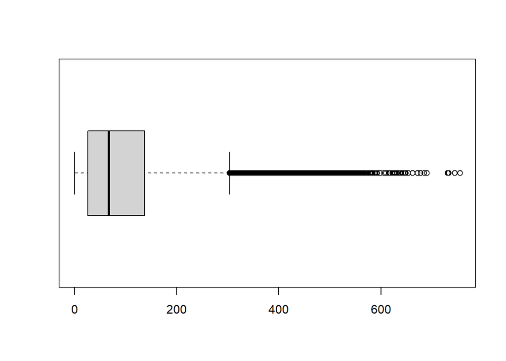

```r
boxplot(datos$EmploymentStatusDuration, horizontal = T)
```

Se observa que hay valores que detecta como outliers, pero aunque la mayoría de las personas que soliciten estos créditos tengan poco tiempo trabajo, también pueden ser solicitados por gente que tenga 60 años trabajados.

A los datos sin valor, le asignamos el valor cero.

```r
datos$EmploymentStatusDuration[is.na(datos$EmploymentStatusDuration)]<-0
```

### 3.0.15 IsBorrowerHomeowner

```r
summary(datos$IsBorrowerHomeowner)
```

```
## False  True
## 56459 57478
```

Se comprueba que no hay datos vacíos. Se observa que la proporción entre personas que son propietarias de una casa y personas que no es semejante.

### 3.0.16 DateCreditPulled

```r
summary(datos$DateCreditPulled)
```

```
##         Min.      1st Qu.       Median         Mean      3rd Qu.         Max.
## "2005-11-09" "2008-09-16" "2012-06-17" "2011-07-09" "2013-09-11" "2014-03-10"
```

No existen valores vacíos. Los datos parecen lógicos. Comprobamos que en su mayoría los valores coinciden con la fecha de creación de listing.

```r
summary(datos$DateCreditPulled==datos$ListingCreationDate)
```

```
##    Mode   FALSE    TRUE
## logical   32482   81455
```

Si los convertimos a numero, observamos que la correlación entre ambas variables es muy elevada. Eliminamos la variable.

```r
cor(sapply(datos[,c(1,13)],as.numeric))
```

```
##                     ListingCreationDate DateCreditPulled
## ListingCreationDate           1.0000000        0.9995438
## DateCreditPulled              0.9995438        1.0000000
```

```r
datos$DateCreditPulled<-NULL
```

### 3.0.17 CreditScoreRangeLower

```r
summary(datos$CreditScoreRangeLower)
```

```
##    Min. 1st Qu.  Median    Mean 3rd Qu.    Max.    NA's
##     0.0   660.0   680.0   685.6   720.0   880.0     591
```

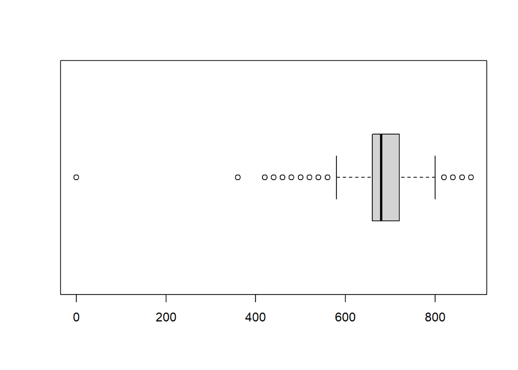

```r
boxplot(datos$CreditScoreRangeLower, horizontal = T)
```

Existen valores vacíos. Su gestión se deja para posteriormente.

### 3.0.18 CreditScoreRangeUpper

Hacemos lo mismo que en la variable anterior.

```r
summary(datos$CreditScoreRangeUpper)
```

```
##    Min. 1st Qu.  Median    Mean 3rd Qu.    Max.    NA's
##    19.0   679.0   699.0   704.6   739.0   899.0     591
```

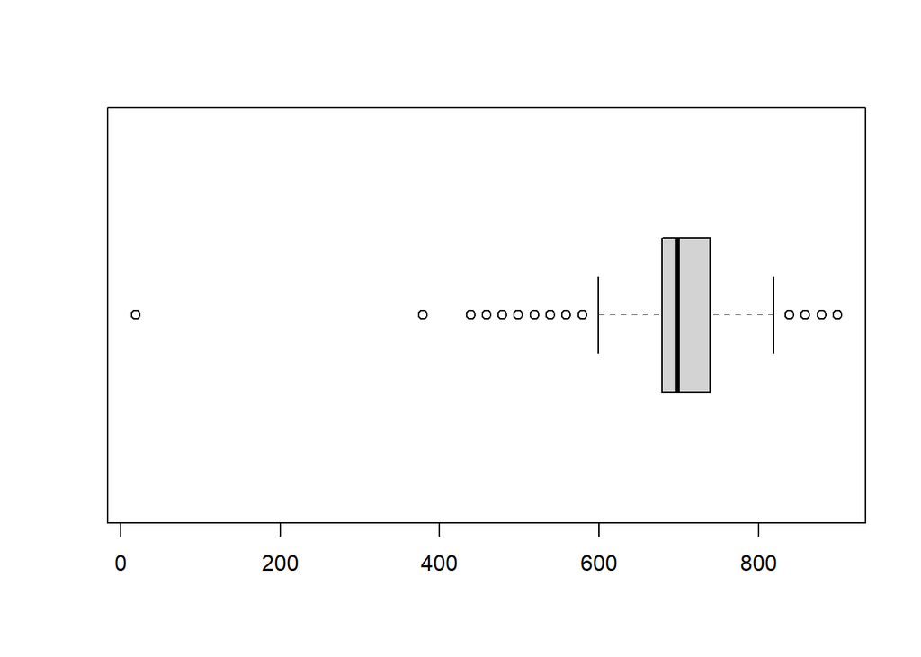

```r
boxplot(datos$CreditScoreRangeUpper, horizontal = T)
```

Existen valores vacíos. Su gestión se deja para posteriormente.

### 3.0.19 FirstRecordedCreditLine

```r
summary(datos$FirstRecordedCreditLine)
```

```
##         Min.      1st Qu.       Median         Mean      3rd Qu.         Max.
## "1947-08-24" "1990-06-01" "1995-11-01" "1994-11-17" "2000-03-14" "2012-12-22"
##         NA's
##        "697"
```

Existen valores vacíos. Entendemos que son las personas que no cuentan con una línea de crédito. Dejaremos el valor vacío.

### 3.0.20 OpenCreditLines

```r
summary(datos$OpenCreditLines)
```

```
##    Min. 1st Qu.  Median    Mean 3rd Qu.    Max.    NA's
##    0.00    6.00    9.00    9.26   12.00   54.00    7604
```

Observamos que existen más registros vacíos que sin fecha. En los que no consta fecha se introduce un cero, en los que sí se introducirá el valor medio.

```r
media<-as.integer(mean(datos$OpenCreditLines,na.rm = T))

for (i in (1:(dim(datos)[1])))
  {
#asignamos a los valoresvacíos
      if  (is.na(datos$OpenCreditLines[i])){
        if(is.na(datos$FirstRecordedCreditLine[i])){
          datos$OpenCreditLines[i]<-0
        }
        else{
          datos$OpenCreditLines[i]<-media
        }
      }

}

remove(i,media)
```

### 3.0.21 OpenRevolvingMonthlyPayment

```r
summary(datos$OpenRevolvingMonthlyPayment)
```

```
##    Min. 1st Qu.  Median    Mean 3rd Qu.    Max.
##     0.0   114.0   271.0   398.3   525.0 14985.0
```

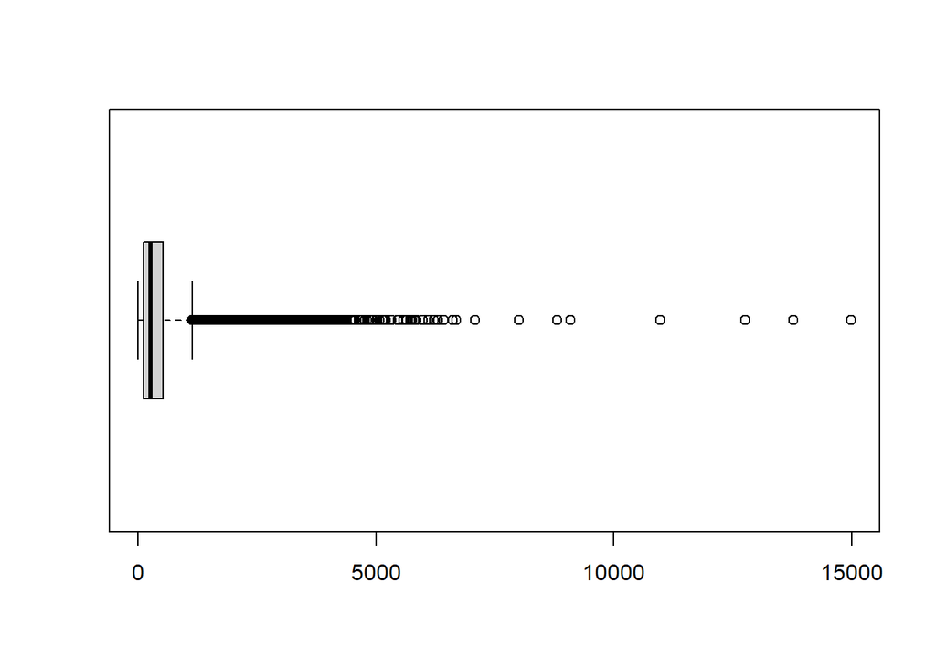

```r
boxplot(datos$OpenRevolvingMonthlyPayment,horizontal = T)
```

No hay datos vacíos, aunque observamos valores muy altos que podríamos considerar anormales.

```r
#valores más altos
head(datos[order(datos$OpenRevolvingMonthlyPayment, decreasing=TRUE),],10)
```

```
##        ListingCreationDate Term LoanStatus ClosedDate BorrowerAPR
## 16742           2008-05-12   36 Chargedoff 2009-11-17     0.19730
## 85535           2013-02-12   60    Current 2010-01-29     0.21566
## 62275           2007-10-21   36  Completed 2010-10-29     0.17260
## 40277           2008-05-17   36  Completed 2011-05-28     0.14448
## 21632           2008-01-14   36  Completed 2008-03-07     0.14923
## 91943           2006-07-30   36 Chargedoff 2009-04-12     0.25205
## 44920           2008-02-27   36  Defaulted 2009-06-12     0.20572
## 32027           2014-02-27   36    Current 2017-09-03     0.22966
## 100153          2007-01-11   36  Completed 2008-01-28     0.14759
## 15627           2007-08-31   36  Defaulted 2009-05-06     0.21237
##        EstimatedEffectiveYield ProsperScore BorrowerState          Occupation
## 16742                       NA           NA            MI        Professional
## 85535                   0.1702            5            MI       Skilled Labor
## 62275                       NA           NA            CA            Attorney
```

[output cut: 172 more lines]

Si las comparamos con respecto a los ingresos mensuales declarados, observamos que la mayoría de las cuotas revolving más altas se corresponden a los mayores ingresos correspondientes.

Aun así, corregimos con la medialos que presenten una cuota mayor que los ingresos.

```r
datos$OpenRevolvingMonthlyPayment[datos$OpenRevolvingMonthlyPayment>
                                    datos$StatedMonthlyIncome]<-as.integer(
                                      mean(datos$OpenRevolvingMonthlyPayment))
```

### 3.0.22 InquiriesLast6Month

```r
summary(datos$InquiriesLast6Months)
```

```
##    Min. 1st Qu.  Median    Mean 3rd Qu.    Max.    NA's
##   0.000   0.000   1.000   1.435   2.000 105.000     697
```

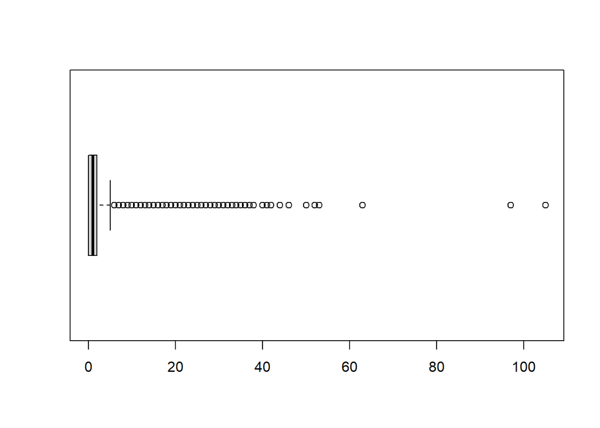

```r
boxplot(datos$InquiriesLast6Months, horizontal = T)
```

Existen valores muy altos que podrían considerarse anómalos. Considerando un total de 20 días “laborables” al mes, en 6 meses el caso máximo requeriría al menos una solicitud el 87,5% de los días, por lo tanto es posible.

En el caso de los valores vacíos, consideramos que no han existido peticiones.

```r
datos$InquiriesLast6Months[is.na(datos$InquiriesLast6Months)]<-0
```

### 3.0.23 TotalInquiries

```r
summary(datos$TotalInquiries)
```

```
##    Min. 1st Qu.  Median    Mean 3rd Qu.    Max.    NA's
##   0.000   2.000   4.000   5.584   7.000 379.000    1159
```

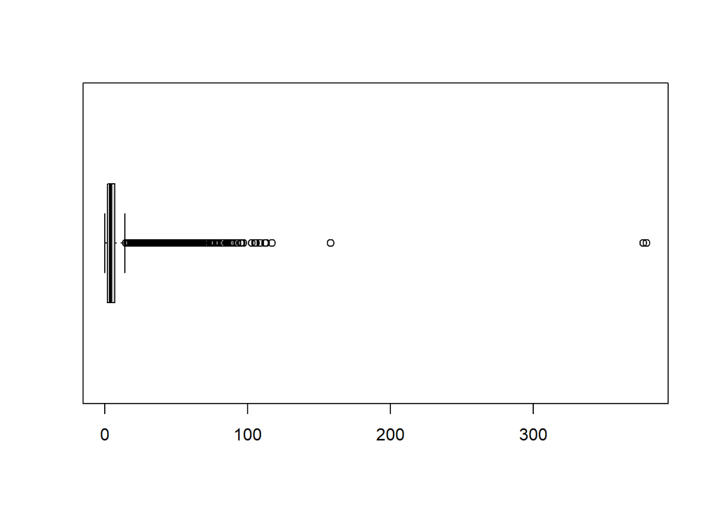

```r
boxplot(datos$TotalInquiries, horizontal = T)
```

COmo en el caso anterior, observamos valores muy grandes que se alejan de la distribución. No disponemos del conocimiento para saber si puede existir un solicitante con este perfil. Además, en este caso el período de tiempo en el que se han generado dichas solicitudes no se conoce y será diferente para cada solicitante.

Comprobamos que los valores disponibles son correctos.

```r
summary(datos$TotalInquiries>=datos$InquiriesLast6Months)
```

```
##    Mode    TRUE    NA's
## logical  112778    1159
```

Para los valores NA, asignaremos el valor de los 6 meses. Habiendo ya sido corregido previamente, siempre asignaremos un valor válido.

```r
datos$TotalInquiries[is.na(datos$TotalInquiries)]<-datos$InquiriesLast6Months
```

### 3.0.24 CurrentDeliquincies

```r
summary(datos$CurrentDelinquencies)
```

```
##    Min. 1st Qu.  Median    Mean 3rd Qu.    Max.    NA's
##  0.0000  0.0000  0.0000  0.5921  0.0000 83.0000     697
```

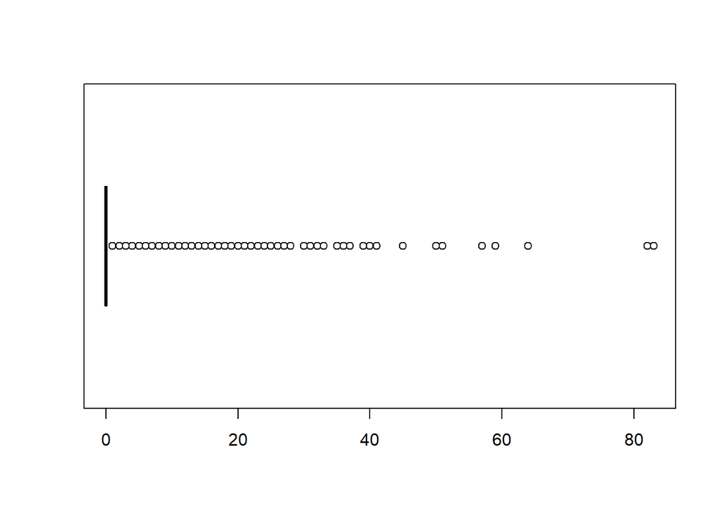

```r
boxplot(datos$CurrentDelinquencies, horizontal = T)
```

Vemos que normalmente la distribución de dicha variable presenta ceros; este valor será asignado a los valores vacíos.

```r
datos$CurrentDelinquencies[is.na(datos$CurrentDelinquencies)]<-0
```

### 3.0.25 AmountDeliquent

```r
summary(datos$AmountDelinquent)
```

```
##     Min.  1st Qu.   Median     Mean  3rd Qu.     Max.     NA's
##      0.0      0.0      0.0    984.5      0.0 463881.0     7622
```

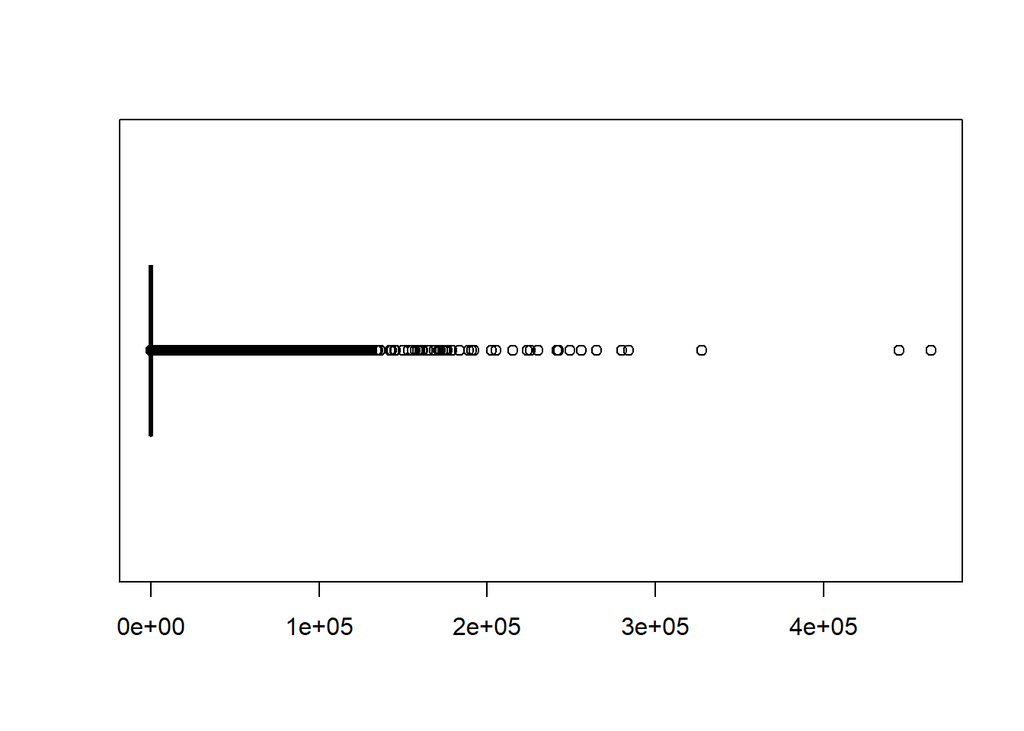

```r
boxplot(datos$AmountDelinquent, horizontal = T)
```

```r
# deuda media por cada deuda
media<-as.integer(mean(datos$AmountDelinquent/ifelse(datos$CurrentDelinquencies==0,NA,datos$CurrentDelinquencies), na.rm = TRUE))
datos$AmountDelinquent[is.na(datos$AmountDelinquent)]<-datos$CurrentDelinquencies*media

remove(media)
```

### 3.0.26 PublicRecordsLast12Months

```r
summary(datos$PublicRecordsLast12Months)
```

```
##    Min. 1st Qu.  Median    Mean 3rd Qu.    Max.    NA's
##   0.000   0.000   0.000   0.015   0.000  20.000    7604
```

En este caso, no disponemos de otros datos, imputamos un cero a los valores vacíos.

```r
datos$PublicRecordsLast12Months[is.na(datos$PublicRecordsLast12Months)]<-0
```

### 3.0.27 RevolvingCreditBalance

```r
summary(datos$RevolvingCreditBalance)
```

```
##    Min. 1st Qu.  Median    Mean 3rd Qu.    Max.    NA's
##       0    3121    8549   17599   19521 1435667    7604
```

Comprobamos si existe correlación con ciertas variables:

```r
cor(sapply(datos[,c(17,23,29,32)],as.numeric),use="complete.obs")
```

```
##                             OpenRevolvingMonthlyPayment RevolvingCreditBalance
## OpenRevolvingMonthlyPayment                   1.0000000             0.75691177
## RevolvingCreditBalance                        0.7569118             1.00000000
## DebtToIncomeRatio                             0.0740582             0.03863646
## StatedMonthlyIncome                           0.3161159             0.30371186
##                             DebtToIncomeRatio StatedMonthlyIncome
## OpenRevolvingMonthlyPayment        0.07405820           0.3161159
## RevolvingCreditBalance             0.03863646           0.3037119
## DebtToIncomeRatio                  1.00000000          -0.1253415
## StatedMonthlyIncome               -0.12534155           1.0000000
```

Aunque el coeficiente no es todo lo bueno que se desea, decidimos plantear un modelo que relacione el balance con la cuota de créditos revolving.

```r
reg.revolving<-lm(RevolvingCreditBalance ~ OpenRevolvingMonthlyPayment,datos,na.action = na.omit)

summary(reg.revolving)
```

```
##
## Call:
## lm(formula = RevolvingCreditBalance ~ OpenRevolvingMonthlyPayment,
##     data = datos, na.action = na.omit)
##
## Residuals:
##     Min      1Q  Median      3Q     Max
## -647714   -6055    -327    3635  873100
##
## Coefficients:
##                               Estimate Std. Error t value Pr(>|t|)
## (Intercept)                 -5662.8212    91.6478  -61.79   <2e-16 ***
## OpenRevolvingMonthlyPayment    56.4628     0.1524  370.38   <2e-16 ***
## ---
## Signif. codes:  0 '***' 0.001 '**' 0.01 '*' 0.05 '.' 0.1 ' ' 1
##
## Residual standard error: 21760 on 106331 degrees of freedom
##   (7604 observations deleted due to missingness)
## Multiple R-squared:  0.5633, Adjusted R-squared:  0.5633
## F-statistic: 1.372e+05 on 1 and 106331 DF,  p-value: < 2.2e-16
```

```r
remove(reg.revolving)
```

Se observa que el r2 ajustado del modelo no es bueno.

Se imputa la media.

```r
datos$RevolvingCreditBalance[is.na(datos$RevolvingCreditBalance)]<-
  mean(datos$RevolvingCreditBalance,na.rm = T)
```

### 3.0.28 BankCardUtilization

```r
summary(datos$BankcardUtilization)
```

```
##    Min. 1st Qu.  Median    Mean 3rd Qu.    Max.    NA's
##   0.000   0.310   0.600   0.561   0.840   5.950    7604
```

Se imputa la media.

```r
datos$BankcardUtilization[is.na(datos$BankcardUtilization)]<-
  mean(datos$BankcardUtilization,na.rm = T)
```

### 3.0.29 AvailableBankcardCredit

```r
summary(datos$AvailableBankcardCredit)
```

```
##    Min. 1st Qu.  Median    Mean 3rd Qu.    Max.    NA's
##       0     880    4100   11210   13180  646285    7544
```

```r
cor(sapply(datos[,c(25,29,32)],as.numeric),use="complete.obs")
```

```
##                         AvailableBankcardCredit DebtToIncomeRatio
## AvailableBankcardCredit             1.000000000       0.002058548
## DebtToIncomeRatio                   0.002058548       1.000000000
## StatedMonthlyIncome                 0.173104460      -0.125347393
##                         StatedMonthlyIncome
## AvailableBankcardCredit           0.1731045
## DebtToIncomeRatio                -0.1253474
## StatedMonthlyIncome               1.0000000
```

Ante la ausencia de relación, se imputa la media.

```r
datos$AvailableBankcardCredit[is.na(datos$AvailableBankcardCredit)]<-
  as.integer(mean(datos$AvailableBankcardCredit,na.rm = T))
```

### 3.0.30 Trades (TradesOpenedLast6Months/TradesNeverDelinquent..percentage./TotalTrades)

```r
summary(datos$TradesOpenedLast6Months)
```

```
##    Min. 1st Qu.  Median    Mean 3rd Qu.    Max.    NA's
##   0.000   0.000   0.000   0.802   1.000  20.000    7544
```

```r
summary(datos$TradesNeverDelinquent..percentage.)
```

```
##    Min. 1st Qu.  Median    Mean 3rd Qu.    Max.    NA's
##   0.000   0.820   0.940   0.886   1.000   1.000    7544
```

```r
summary(datos$TotalTrades)
```

```
##    Min. 1st Qu.  Median    Mean 3rd Qu.    Max.    NA's
##    0.00   15.00   22.00   23.23   30.00  126.00    7544
```

Se comprueba que la mayoría de las financiaciones comerciales no inciden en morosidad.

Comprobamos que los datos totales sean correctos.

```r
summary(datos$TradesOpenedLast6Months<=datos$TotalTrades)
```

```
##    Mode    TRUE    NA's
## logical  106393    7544
```

Partimos de que no se han producido este tipo de financiaciones si no hay datos, según lo recogido en el documento facilitado con el dataset.

```r
datos$TradesOpenedLast6Months[is.na(datos$TradesOpenedLast6Months)]<-0
datos$TradesNeverDelinquent..percentage.[is.na(datos$TradesNeverDelinquent..percentage.)]<-0
datos$TotalTrades[is.na(datos$TotalTrades)]<-datos$TradesOpenedLast6Months
```

Los porcentajes del dataset están dados en tanto por uno.

```r
summary(datos$DebtToIncomeRatio)
```

```
##    Min. 1st Qu.  Median    Mean 3rd Qu.    Max.    NA's
##   0.000   0.140   0.220   0.276   0.320  10.010    8554
```

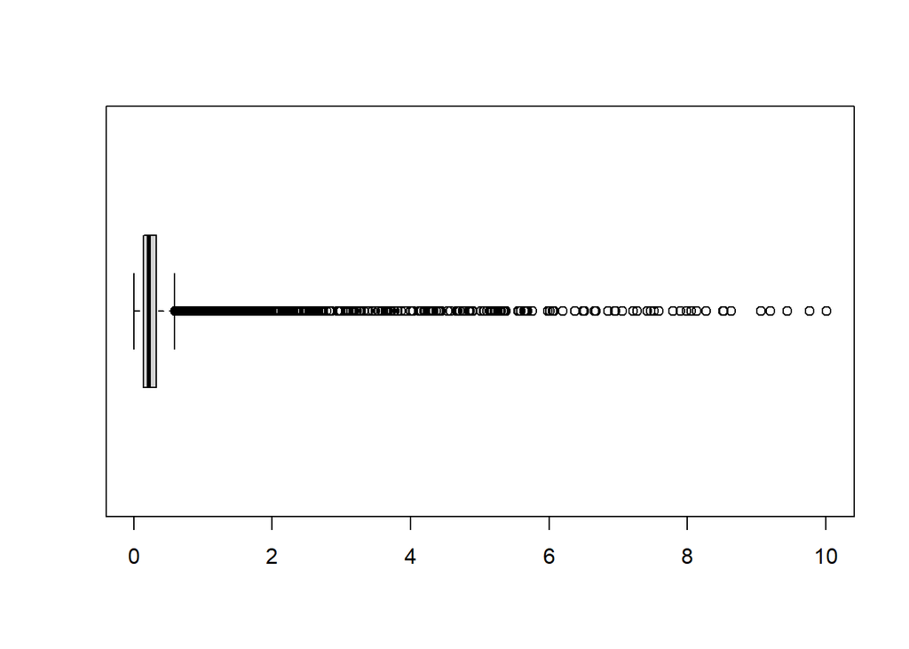

```r
boxplot(datos$DebtToIncomeRatio,horizontal = T)
```

Así, observamos que de media los solicitantes tienen una deuda que representa el 27,6% de sus ingresos.

Se ha creado un modelo para predecir el valor, sin embargo el resultado no ha sido bueno.

```r
summary(lm(DebtToIncomeRatio~Term+EstimatedEffectiveYield+OpenCreditLines+
             OpenRevolvingMonthlyPayment+InquiriesLast6Months+RevolvingCreditBalance+
             TotalTrades+IncomeRange,datos,na.action=na.omit))
```

```
##
## Call:
## lm(formula = DebtToIncomeRatio ~ Term + EstimatedEffectiveYield +
##     OpenCreditLines + OpenRevolvingMonthlyPayment + InquiriesLast6Months +
##     RevolvingCreditBalance + TotalTrades + IncomeRange, data = datos,
##     na.action = na.omit)
##
## Residuals:
##     Min      1Q  Median      3Q     Max
## -0.6815 -0.0711 -0.0107  0.0511  9.8823
##
## Coefficients:
##                               Estimate Std. Error t value Pr(>|t|)
## (Intercept)                  4.174e-01  6.890e-03  60.583  < 2e-16 ***
## Term                        -2.794e-04  9.179e-05  -3.044  0.00234 **
## EstimatedEffectiveYield      4.512e-01  1.712e-02  26.351  < 2e-16 ***
## OpenCreditLines              8.892e-03  3.091e-04  28.767  < 2e-16 ***
## OpenRevolvingMonthlyPayment  1.201e-04  4.507e-06  26.651  < 2e-16 ***
## InquiriesLast6Months        -9.951e-03  8.093e-04 -12.297  < 2e-16 ***
## RevolvingCreditBalance      -5.241e-07  5.270e-08  -9.945  < 2e-16 ***
## TotalTrades                  1.206e-03  1.188e-04  10.155  < 2e-16 ***
## IncomeRange$100,000+        -4.796e-01  5.779e-03 -83.002  < 2e-16 ***
## IncomeRange$25,000-49,999   -3.214e-01  5.216e-03 -61.611  < 2e-16 ***
## IncomeRange$50,000-74,999   -3.770e-01  5.282e-03 -71.379  < 2e-16 ***
## IncomeRange$75,000-99,999   -4.222e-01  5.616e-03 -75.177  < 2e-16 ***
## IncomeRangeNot employed     -2.696e-01  2.958e-01  -0.911  0.36211
## ---
## Signif. codes:  0 '***' 0.001 '**' 0.01 '*' 0.05 '.' 0.1 ' ' 1
##
## Residual standard error: 0.2957 on 77479 degrees of freedom
##   (36445 observations deleted due to missingness)
## Multiple R-squared:  0.137,  Adjusted R-squared:  0.1368
## F-statistic:  1025 on 12 and 77479 DF,  p-value: < 2.2e-16
```

Se imputa el valor medio.

```r
datos$DebtToIncomeRatio[is.na(datos$DebtToIncomeRatio)]<-
  as.integer(mean(datos$DebtToIncomeRatio,na.rm = T))
```

### 3.0.31 IncomeRange

```r
summary(datos$IncomeRange)
```

```
##             $0      $1-24,999      $100,000+ $25,000-49,999 $50,000-74,999
##            621           7274          17337          32192          31050
## $75,000-99,999  Not displayed   Not employed
##          16916           7741            806
```

Todos los datos pertencen a alguno de las categorías de las variables.

### 3.0.32 IncomeVerifiable

```r
summary(datos$IncomeVerifiable)
```

```
##  False   True
##   8669 105268
```

Todos los registros presentan un nivel válido.

Para hacer un análisis riguroso de los perfiles y préstamos, *se va a descartar los perfiles con ingresos no verificables.* El impacto es pequeño, representan el 7,6% de los datos del dataset.

```r
datos<-subset(datos,IncomeVerifiable=="True")
#eliminamos la columna
datos$IncomeVerifiable<-NULL
```

### 3.0.33 StatedMonthlyIncome

```r
summary(datos$StatedMonthlyIncome)
```

```
##    Min. 1st Qu.  Median    Mean 3rd Qu.    Max.
##       0    3333    4750    5656    6853  483333
```

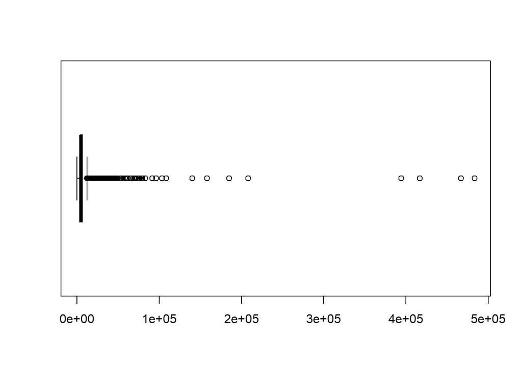

```r
boxplot(datos$StatedMonthlyIncome, horizontal = T)
```

Se observa que por encima de los 100.000 dólares mensuales no hay un gran número de perfiles. Todo apunta a valor incorrecto, pudiendo ser los ingresos anuales y no los mensuales. No disponemos de datos en base a los cuales realizar la corrección.

En este punto, comprobamos que la información es redundante con la variable IncomeRange, de hecho en este caso tenemos datos de todos los registros. Y podremos consultar si está desempleado, en la variable correspondiente.

```r
datos$IncomeRange <-NULL
```

### 3.0.34 ProsperLoans

Tratamos de forma conjunta los préstamos Prosper anteriores.

```r
summary(datos$TotalProsperLoans)
```

```
##    Min. 1st Qu.  Median    Mean 3rd Qu.    Max.    NA's
##    0.00    1.00    1.00    1.42    2.00    8.00   85364
```

```r
summary(datos$OnTimeProsperPayments)
```

```
##    Min. 1st Qu.  Median    Mean 3rd Qu.    Max.    NA's
##    0.00    1.00    1.00    0.97    1.00    1.00   85422
```

```r
summary(datos$ProsperPrincipalOutstanding)
```

```
##    Min. 1st Qu.  Median    Mean 3rd Qu.    Max.    NA's
##       0       0    1663    2980    4187   23451   85364
```

```r
datos$TotalProsperLoans[is.na(datos$TotalProsperLoans)]<-0
```

En el caso de la segunda variable, se comprueba que la mayoría de los solicitante son buenos pagadores. Imputamos valor 1 a los registros vacíos (se supone que no tienen préstamos previos).

```r
datos$OnTimeProsperPayments[is.na(datos$OnTimeProsperPayments)]<-1
```

En el caso de la tercera variable, imputamos ceros porque no hay préstamos previos, y por tanto no hay ninguna cantidad pendiente de pago.

```r
datos$ProsperPrincipalOutstanding[is.na(datos$ProsperPrincipalOutstanding)]<-0
```

Comprobamos también que para la mayoría de solicitantes, esta es la primera vez que piden un préstamos Prosper.

### 3.0.35 LoanCurrentDaysDelinquent

```r
summary(datos$LoanCurrentDaysDelinquent)
```

```
##    Min. 1st Qu.  Median    Mean 3rd Qu.    Max.
##     0.0     0.0     0.0   153.6     0.0  2704.0
```

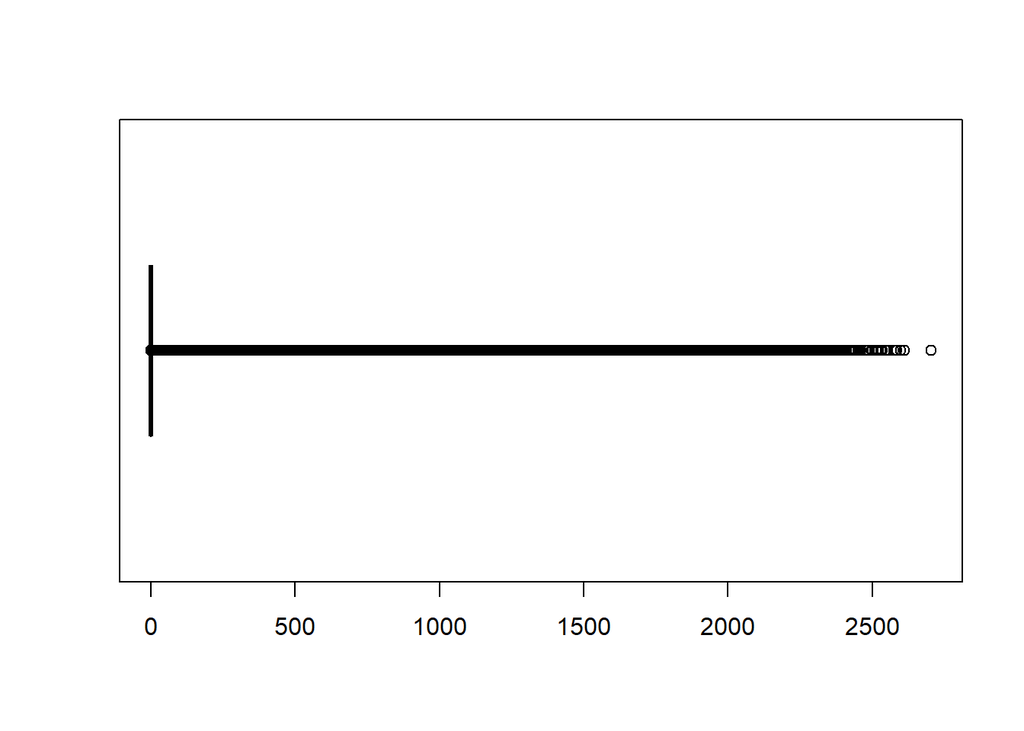

```r
boxplot(datos$LoanCurrentDaysDelinquent, horizontal = T)
```

Se observa que no hay valores vacíos. Comprobamos que la mayoría de los préstamos no presentan impagos de las cuotas. Nos interesa mantener los valores superiores a cero para identificar los préstamos morosos y poder identificar el perfil de solicitante que incurre en morosidad.

### 3.0.36 LoanOriginalAmount

```r
summary(datos$LoanOriginalAmount)
```

```
##    Min. 1st Qu.  Median    Mean 3rd Qu.    Max.
##    1000    4000    6500    8438   12000   35000
```

Ya se ha graficado previamente, no hay valores vacíos y observamos que la mayoría del dinero solicitado se sitúa en el rango entre 4.000 y 12.000 dólares.

### 3.0.37 LoanOriginationDate

```r
summary(datos$LoanOriginationDate)
```

```
##         Min.      1st Qu.       Median         Mean      3rd Qu.         Max.
## "2005-11-15" "2008-09-03" "2012-06-29" "2011-07-09" "2013-09-19" "2014-03-12"
```

No hay valores vacíos y son coherentes con respecto al resto de datos.

Hacemos la correlación con respecto a la fecha de creación.

```r
cor(sapply(datos[,c("ListingCreationDate","LoanOriginationDate")],as.numeric))
```

```
##                     ListingCreationDate LoanOriginationDate
## ListingCreationDate           1.0000000           0.9995658
## LoanOriginationDate           0.9995658           1.0000000
```

```r
summary(lm(ListingCreationDate~LoanOriginationDate, as.data.frame(sapply(datos[,c("ListingCreationDate","LoanOriginationDate")],as.numeric))))
```

```
##
## Call:
## lm(formula = ListingCreationDate ~ LoanOriginationDate, data = as.data.frame(sapply(datos[,
##     c("ListingCreationDate", "LoanOriginationDate")], as.numeric)))
##
## Residuals:
##      Min       1Q   Median       3Q      Max
## -1082.48    -0.27     3.99     6.82    13.52
##
## Coefficients:
##                       Estimate Std. Error  t value Pr(>|t|)
## (Intercept)         -2.870e+01  1.382e+00   -20.77   <2e-16 ***
## LoanOriginationDate  1.001e+00  9.095e-05 11006.67   <2e-16 ***
## ---
## Signif. codes:  0 '***' 0.001 '**' 0.01 '*' 0.05 '.' 0.1 ' ' 1
##
## Residual standard error: 27.32 on 105266 degrees of freedom
## Multiple R-squared:  0.9991, Adjusted R-squared:  0.9991
## F-statistic: 1.211e+08 on 1 and 105266 DF,  p-value: < 2.2e-16
```

```r
datos$LoanOriginationDate<-NULL
```

Comprobamos que si bien no son idénticos, la semejanza entre ambos valores es muy importante por lo que decidimos eliminar la variable.

### 3.0.38 MonthlyLoanPayment

```r
summary(datos$MonthlyLoanPayment)
```

```
##    Min. 1st Qu.  Median    Mean 3rd Qu.    Max.
##     0.0   131.1   219.9   274.2   372.7  2251.5
```

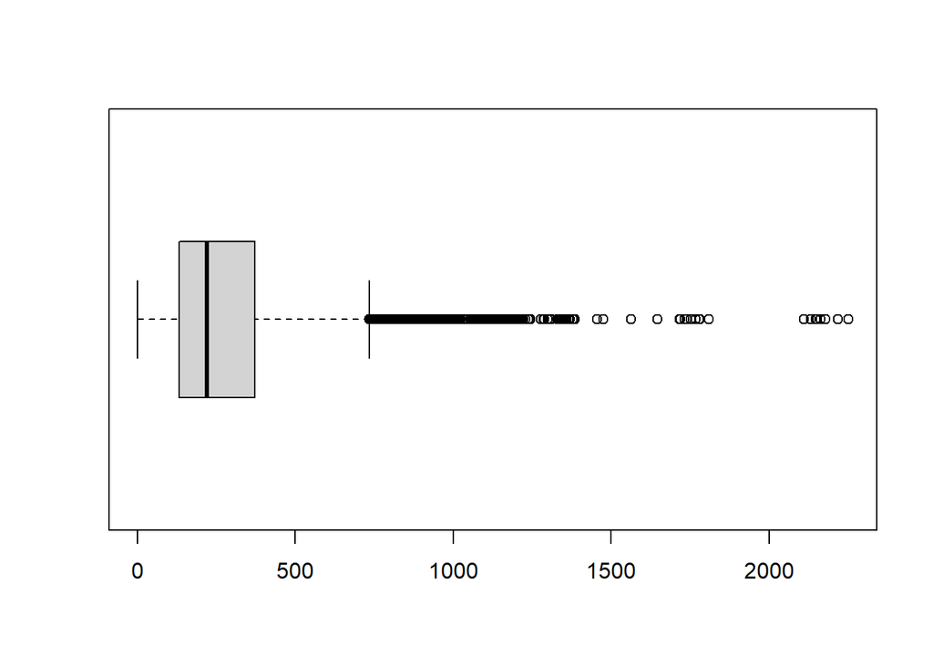

```r
boxplot(datos$MonthlyLoanPayment, horizontal = T)
```